# Đồ án kết thúc học phần

Họ tên: Chu Thị Bảo Ngọc - MSHV: 22C01035

## **Hoạt động 1.2:**

- Dataset insurance.csv:

```r
library(car)
library(Hmisc)
library(magrittr)
library(dplyr)
```

```r
library(ggplot2)
library(ggpubr)
library(ggfortify)
library(agricolae)
library(EnvStats)
insurance <- read.csv("insurance.csv")
dim(insurance)
```

```
## [1] 1338    7
```

Có thể thấy bộ dữ liệu bao gồm 1338 quan trắc và 7 biến.

```r
head(insurance)
```

|  | age | sex | bmi | children | smoker | region | charges |
| --- | --- | --- | --- | --- | --- | --- | --- |
| 1 | 19 | female | 27.900 | 0 | yes | southwest | 16884.924 |
| 2 | 18 | male | 33.770 | 1 | no | southeast | 1725.552 |
| 3 | 28 | male | 33.000 | 3 | no | southeast | 4449.462 |
| 4 | 33 | male | 22.705 | 0 | no | northwest | 21984.471 |
| 5 | 32 | male | 28.880 | 0 | no | northwest | 3866.855 |
| 6 | 31 | female | 25.740 | 0 | no | southeast | 3756.622 |

#### **Giới thiệu bộ dữ liệu:**

Bộ dữ liệu insurance.csv chứa các thông tin về số tiền bảo hiểm dùng trong y tế cho những người dân ở Mỹ. Dữ liệu gốc được cung cấp tại:

https://www.kaggle.com/datasets/mirichoi0218/insurance

Bộ dữ liệu gồm 1338 quan trắc và 7 biến sau:

- “age”: độ tuổi của người sử dụng quyền lợi bảo hiểm y tế,
- “sex”: giới tính của người sử dụng bảo hiểm y tế (male/female),
- “bmi”: chỉ số BMI,
- “children”: số người phụ thuộc (con),
- “smoker”: người sử dụng bảo hiểm có hút thuốc hay không (yes/no),
- “region”: vùng sinh sống của người sở hữu bảo hiểm y tế,
- “charges”: chi phí bảo hiểm y tế chi trả cho người được khảo sát.

#### **Mục tiêu:**

Ta sẽ áp dụng phương pháp phân tích phương sai nhiều nhân tố (ANOVA k nhân tố với $k \geq 3$) để xem xét các nhân tố về vùng sinh sống, giới tính, việc hút thuốc, độ tuổi, … của một người có ảnh hưởng tới chi phí bảo hiểm y tế chi trả cho người đó như thế nào.

### (a) Tiền xử lý dữ liệu:

```r
str(insurance)
```

```
## 'data.frame':    1338 obs. of  7 variables:
##  $ age     : int  19 18 28 33 32 31 46 37 37 60 ...
##  $ sex     : chr  "female" "male" "male" "male" ...
##  $ bmi     : num  27.9 33.8 33 22.7 28.9 ...
##  $ children: int  0 1 3 0 0 0 1 3 2 0 ...
##  $ smoker  : chr  "yes" "no" "no" "no" ...
##  $ region  : chr  "southwest" "southeast" "southeast" "northwest" ...
##  $ charges : num  16885 1726 4449 21984 3867 ...
```

Ta thấy bộ dữ liệu có 3 biến định tính là “sex”, “smoker”, “region”. Vậy đầu tiên ta đưa các biến này về dạng nhân tố:

```r
# Đưa các biến định tính về dạng nhân tố
insurance$sex <- as.factor(insurance$sex)
insurance$smoker <- as.factor(insurance$smoker)
insurance$region <- as.factor(insurance$region)
```

```r
summary(insurance)
```

```
##       age            sex           bmi           children     smoker
##  Min.   :18.00   female:662   Min.   :15.96   Min.   :0.000   no :1064
##  1st Qu.:27.00   male  :676   1st Qu.:26.30   1st Qu.:0.000   yes: 274
##  Median :39.00                Median :30.40   Median :1.000
##  Mean   :39.21                Mean   :30.66   Mean   :1.095
##  3rd Qu.:51.00                3rd Qu.:34.69   3rd Qu.:2.000
##  Max.   :64.00                Max.   :53.13   Max.   :5.000
##        region       charges
##  northeast:324   Min.   : 1122
##  northwest:325   1st Qu.: 4740
##  southeast:364   Median : 9382
##  southwest:325   Mean   :13270
##                  3rd Qu.:16640
##                  Max.   :63770
```

Từ kết quả hàm summary(), nhận xét rằng:

- Những người sử dụng quyền lợi bảo hiểm y tế có độ tuổi trung bình là 39, chỉ số BMI trung bình là 30.66, số con trung bình là 1, chi phí bảo hiểm y tế trung bình là 13270.
- Sự chênh lệch về giới tính giữa những người sử dụng quyền lợi bảo hiểm y tế là không đáng kể.
- Số lượng người sử dụng quyền lợi bảo hiểm y tế sinh sống ở 4 vùng là xấp xỉ bằng nhau.
- Số lượng người sử dụng quyền lợi bảo hiểm y tế không hút thuốc nhiều gấp gần 4 lần so với người sử dụng quyền lợi bảo hiểm y tế có hút thuốc.

**Kiểm tra các giá trị khuyết:**

```r
# Kiểm tra các giá trị khuyết
colSums(is.na(insurance))[colSums(is.na(insurance))>0]
```

```
## named numeric(0)
```

Có thể thấy bộ dữ liệu không có biến nào chứa giá trị khuyết.

**Kiểm tra các giá trị ngoại lai của các biến định lượng:**

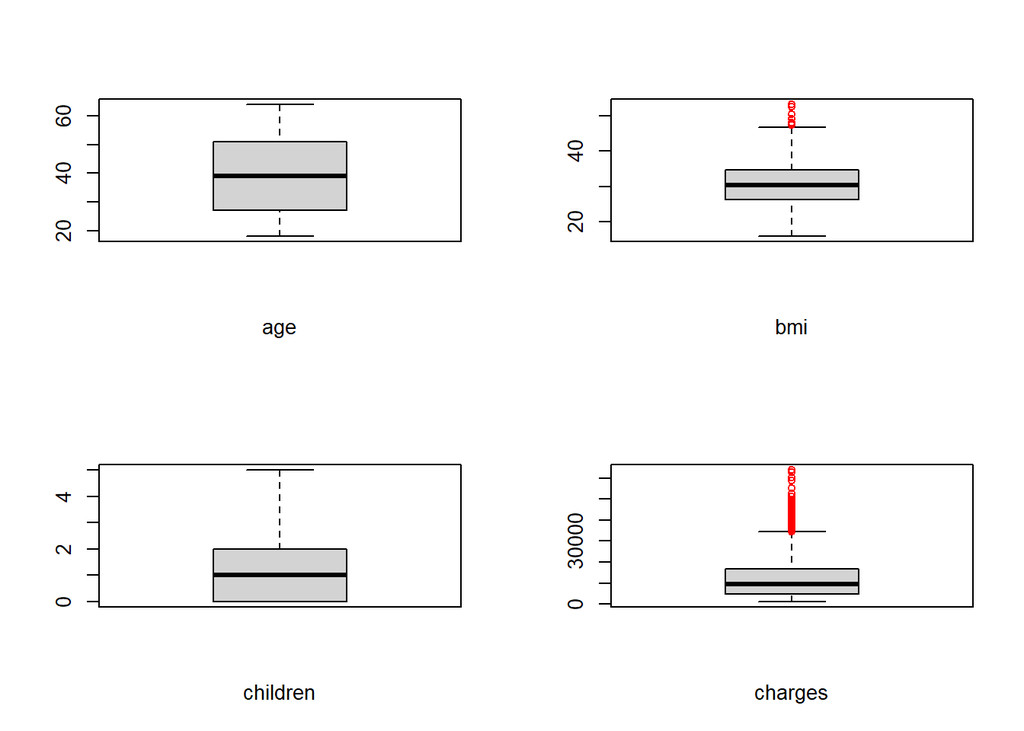

```r
# Kiểm tra các giá trị ngoại lai
# Box - plot
j <- 0
par(mfrow = c(2, 2))
lab <- colnames(subset(insurance, select = -c(sex, smoker, region)))
for (i in subset(insurance, select = -c(sex, smoker, region))){
  j <- j + 1
  boxplot(i, outcol = 'red', xlab = lab[j])
}
```

Theo biểu đồ boxplot, có vẻ như biến “bmi” và “charges” có các giá trị ngoại lai.

Giả sử rằng hai biến “bmi” và “charges” khi không có giá trị ngoại lai thì sẽ tuân theo phân phối chuẩn (*). Khi đó, ta có thể kiểm tra sự hiện diện của giá trị ngoại lai trong các biến này bằng kiểm định Rosner:

*H<sub>0</sub> : Không có giá trị ngoại lai nào.*

*H<sub>1</sub> : Tồn tại từ 1 đến k giá trị ngoại lai.* (k là số lượng giá trị ngoại lai tối đa mà ta dự đoán)

Thuật toán:

1. So sánh thống kê R<sub>k</sub> và giá trị tới hạn $\lambda_{k}$ , nếu $R_{k} > \lambda_{k}$ thì kết luận rằng có k giá trị ngoại lai.
2. Nếu $R_{k} < \lambda_{k}$ thì ta so sánh R<sub>k-1</sub> và $\lambda_{k-1}$ . Nếu $R_{k-1} > \lambda_{k-1}$ thì kết luận rằng có k - 1 giá trị ngoại lai.
3. Lặp lại bước trên đến khi tìm được một số lượng các giá trị ngoại lai hoặc đến khi không tìm được giá trị ngoại lai nào.

```r
# Rosner Test
rosnerTest(insurance$bmi, k = 2)
```

```
##
## Results of Outlier Test
## -------------------------
##
## Test Method:                     Rosner's Test for Outliers
##
## Hypothesized Distribution:       Normal
##
## Data:                            insurance$bmi
##
## Sample Size:                     1338
##
## Test Statistics:                 R.1 = 3.684145
##                                  R.2 = 3.613768
##
## Test Statistic Parameter:        k = 2
##
## Alternative Hypothesis:          Up to 2 observations are not
##                                  from the same Distribution.
##
## Type I Error:                    5%
##
## Number of Outliers Detected:     0
##
##   i   Mean.i     SD.i Value Obs.Num    R.i+1 lambda.i+1 Outlier
## 1 0 30.66340 6.098187 53.13    1318 3.684145   4.110854   FALSE
## 2 1 30.64659 6.069401 52.58    1048 3.613768   4.110674   FALSE
```

```r
rosnerTest(insurance$charges, k = 2)
```

```
##
## Results of Outlier Test
## -------------------------
##
## Test Method:                     Rosner's Test for Outliers
##
## Hypothesized Distribution:       Normal
##
## Data:                            insurance$charges
##
## Sample Size:                     1338
##
## Test Statistics:                 R.1 = 4.170104
##                                  R.2 = 4.101239
##
## Test Statistic Parameter:        k = 2
##
## Alternative Hypothesis:          Up to 2 observations are not
##                                  from the same Distribution.
##
## Type I Error:                    5%
##
## Number of Outliers Detected:     1
##
##   i   Mean.i     SD.i    Value Obs.Num    R.i+1 lambda.i+1 Outlier
## 1 0 13270.42 12110.01 63770.43     544 4.170104   4.110854    TRUE
## 2 1 13232.65 12035.44 62592.87    1301 4.101239   4.110674   FALSE
```

Theo các kết quả kiểm định Rosner với k = 2, biến “bmi” không có giá trị ngoại lai, còn biến “charges” có 1 giá trị ngoại lai là quan trắc thứ 544.

Ta thử sử dụng khoảng cách Mahalanobis để kiểm định xem quan trắc thứ i có là giá trị ngoại lai đa biến hay không:

*H<sub>0</sub> : Quan trắc thứ i không là giá trị ngoại lai đa biến.*

*H<sub>1</sub> : Quan trắc thứ i là giá trị ngoại lai đa biến.*

Ở đây, ta chỉ tính khoảng cách từ giá trị của các biến định lượng.

```r
# Khoảng cách Mahalanobis
insurance_ <- subset(insurance, select = -c(sex, smoker, region))
mahal_dist <- mahalanobis(insurance_, colMeans(insurance_), cov(insurance_), tol=1e-20)
p_vals_mahal <- pchisq(mahal_dist, df = 4 - 1, lower.tail=FALSE)
# df = Số biến định lượng - 1

mahal <- data.frame(mahal_dist, p_vals_mahal)
mahal[p_vals_mahal < 0.001,]
```

|  | mahal_dist | p_vals_mahal |
| --- | --- | --- |
| 439 | 18.45506 | 3.543199e-04 |
| 544 | 22.72569 | 4.606409e-05 |
| 578 | 17.60114 | 5.315217e-04 |
| 1048 | 21.70139 | 7.526105e-05 |
| 1231 | 16.74613 | 7.969893e-04 |
| 1301 | 19.36105 | 2.302032e-04 |
| 1318 | 19.53500 | 2.118882e-04 |

Từ đó, ta thấy với 7 quan trắc bao gồm: quan trắc thứ 439, 544, 578, 1048, 1231, 1301, 1318 thì p - value < 0.001 nên ta bác bỏ H<sub>0</sub> với mức ý nghĩa 0.001 và kết luận rằng các quan trắc này là các giá trị ngoại lai đa biến.

Vì số lượng giá trị ngoại lai khá ít nên ta sẽ tiến hành bỏ các giá trị này ra khỏi bộ dữ liệu:

```r
# Bỏ các giá trị ngoại lai
insurance <- insurance[-c(439, 544, 578, 1048, 1231, 1301, 1318), ]
dim(insurance)
```

```
## [1] 1331    7
```

Như vậy, ta đã xử lý xong các giá trị ngoại lai trong bộ dữ liệu.

### (b) Áp dụng phương pháp ANOVA k nhân tố để xem xét các nhân tố của một người có ảnh hưởng đến chi phí bảo hiểm y tế của người đó như thế nào:

Đầu tiên, ta cần chia cấp độ cho các biến định lượng “age”, “bmi”, “children” trước khi đưa chúng về dạng nhân tố để thực hiện ANOVA. Ta sẽ muốn chia làm sao để số lượng quan trắc trong các cấp độ là xấp xỉ bằng nhau cho từng biến nhằm tránh tình trạng xuất hiện một số nhóm (tổ hợp các cấp độ của các nhân tố) có cỡ mẫu bằng 0 và nhằm đưa thiết kế thí nghiệm về dạng gần cân bằng nhất có thể (cỡ mẫu các nhóm gần bằng nhau).

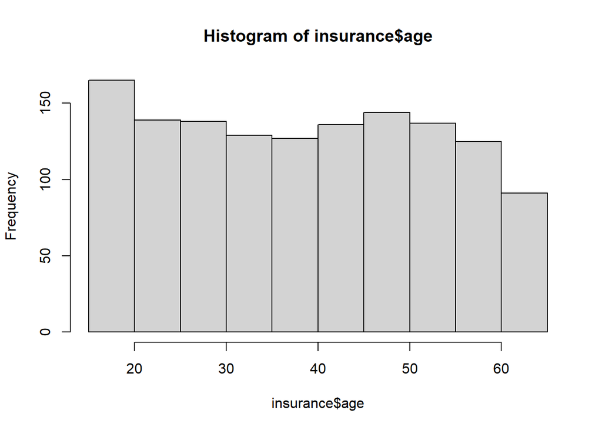

```r
hist(insurance$age)
```

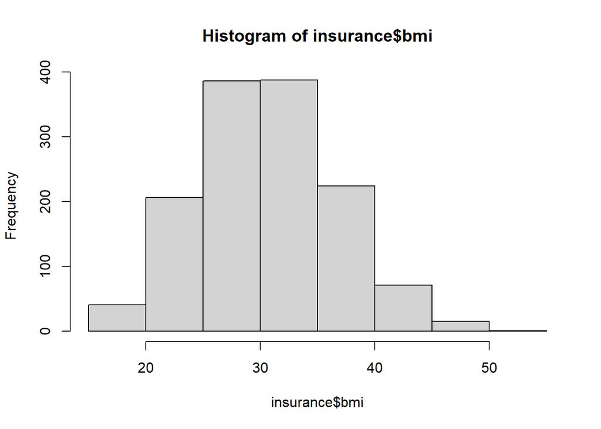

```r
hist(insurance$bmi)
```

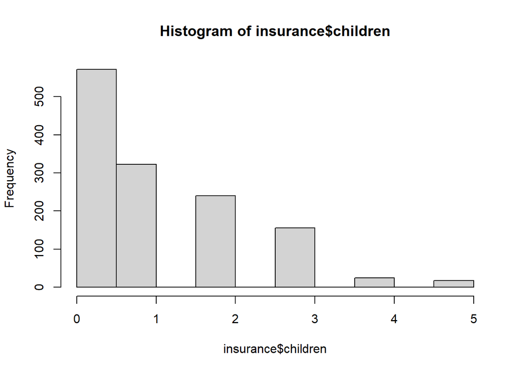

```r
hist(insurance$children)
```

Theo các biểu đồ histogram của ba biến định lượng “age”, “bmi”, “children”, ta thấy:

- Các giá trị của biến “age” được phân bố khá đều trong khoảng từ 18 đến 64. Vì vậy, ta có thể chia biến “age” thành bao nhiêu cấp độ đều được.
- Các giá trị của biến “bmi” tập trung nhiều ở khoảng từ 25 đến 35. Vì vậy, một cách trực quan, ta có thể chia biến “bmi” thành 2 cấp độ: $bmi < 30$ và $bmi \geq 30$.
- Các giá trị của biến “children” chủ yếu tập trung ở giá trị 0. Vì vậy, một cách trực quan, ta có thể chia biến “bmi” thành 2 cấp độ: $children \in \{0,1\}$ và $children \in \{2,3,4,5\}$.

Nay, ta sử dụng hàm cut2() để thực hiện việc chia mỗi biến trên thành 2 cấp độ:

```r
# Chia cấp độ cho các biến định lượng
insurance$age <- cut2(insurance$age, g = 2)
insurance$bmi <- cut2(insurance$bmi, g = 2)
insurance$children <- cut2(insurance$children, g = 2)
summary(insurance$age)
```

```
## [18,40) [40,64]
##     671     660
```

```r
summary(insurance$bmi)
```

```
## [16.0,30.4) [30.4,50.4]
##         667         664
```

```r
summary(insurance$children)
```

```
## [0,2) [2,5]
##   893   438
```

Như vậy, hàm cut2() đã chia biến “age” thành 2 cấp độ là $18 \leq age < 40$ và $40 \leq age \leq 64$ , với số lượng quan trắc lần lượt là 671 và 660. Biến “bmi” được chia thành 2 cấp độ là $16 \leq bmi < 30.4$ và $30.4 \leq bmi \leq 50.4$ , với số lượng quan trắc lần lượt là 667 và 664. Còn biến “children” được chia thành 2 cấp độ là $children \in \{0,1\}$ và $children \in \{2,3,4,5\}$ , với số lượng quan trắc lần lượt là 893 và 438. Điều này tương đối khớp với những gì ta đã nhận xét từ histogram ban nãy, mặc dù cách chia cấp độ của biến children vẫn không đảm bảo được số quan trắc trong hai cấp độ gần bằng nhau, do số lượng quan trắc ứng với $children = 0$ là khá lớn.

```r
str(insurance)
```

```
## 'data.frame':    1331 obs. of  7 variables:
##  $ age     : Factor w/ 2 levels "[18,40)","[40,64]": 1 1 1 1 1 1 2 1 1 2 ...
##  $ sex     : Factor w/ 2 levels "female","male": 1 2 2 2 2 1 1 1 2 1 ...
##  $ bmi     : Factor w/ 2 levels "[16.0,30.4)",..: 1 2 2 1 1 1 2 1 1 1 ...
##  $ children: Factor w/ 2 levels "[0,2)","[2,5]": 1 1 2 1 1 1 1 2 2 1 ...
##  $ smoker  : Factor w/ 2 levels "no","yes": 2 1 1 1 1 1 1 1 1 1 ...
##  $ region  : Factor w/ 4 levels "northeast","northwest",..: 4 3 3 2 2 3 3 2 1 2 ...
##  $ charges : num  16885 1726 4449 21984 3867 ...
```

Như vậy, ta đã đưa tất cả các biến ngoại trừ biến phụ thuộc charges về dạng nhân tố.

Trong phương pháp ANOVA, vì sẽ chỉ làm việc với các nhân tố thay vì các biến định lượng như trong mô hình hồi quy tuyến tính nên ta không cần kiểm tra hiện tượng đa cộng tuyến.

Tiếp theo, ta thử kiểm tra cỡ mẫu của từng nhóm trong thiết kế thí nghiệm (cột Freq trong bảng):

```r
# Số lượng quan trắc (Freq) ứng với từng tổ hợp các cấp độ của các nhân tố
tab <- as.data.frame(with(insurance, table(age, sex, bmi, children, smoker, region)))
head(tab)
```

|  | age | sex | bmi | children | smoker | region | Freq |
| --- | --- | --- | --- | --- | --- | --- | --- |
| 1 | [18,40) | female | [16.0,30.4) | [0,2) | no | northeast | 30 |
| 2 | [40,64] | female | [16.0,30.4) | [0,2) | no | northeast | 20 |
| 3 | [18,40) | male | [16.0,30.4) | [0,2) | no | northeast | 26 |
| 4 | [40,64] | male | [16.0,30.4) | [0,2) | no | northeast | 22 |
| 5 | [18,40) | female | [30.4,50.4] | [0,2) | no | northeast | 16 |
| 6 | [40,64] | female | [30.4,50.4] | [0,2) | no | northeast | 26 |

Vì cỡ mẫu của một số nhóm lớn hơn 1 nên ta sẽ áp dụng phương pháp ANOVA có lặp. Đồng thời, vì cỡ mẫu của các nhóm không bằng nhau nên ta sẽ áp dụng phương pháp ANOVA với thiết kế không cân bằng.

```r
# Kiểm tra nhóm có cỡ mẫu bằng 0
tab[tab$Freq == 0,]
```

| age | sex | bmi | children | smoker | region | Freq |
| --- | --- | --- | --- | --- | --- | --- |

Ta thấy tất cả các nhóm đều có cỡ mẫu lớn hơn 0. Do đó, ta có thể tiến hành xây dựng mô hình ANOVA.

**Đồ thị thể hiện những sự tương tác hai chiều:**

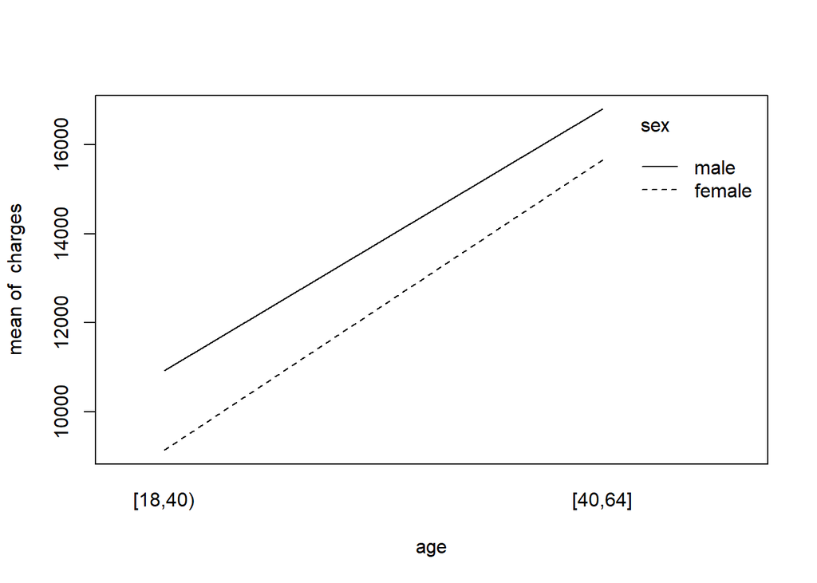

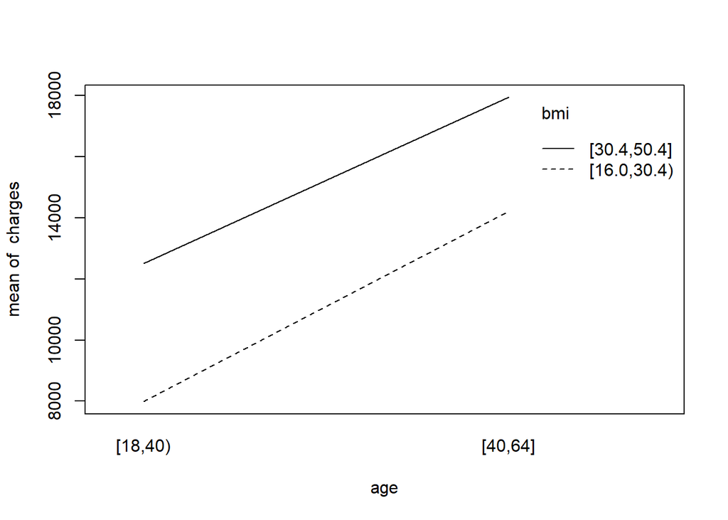

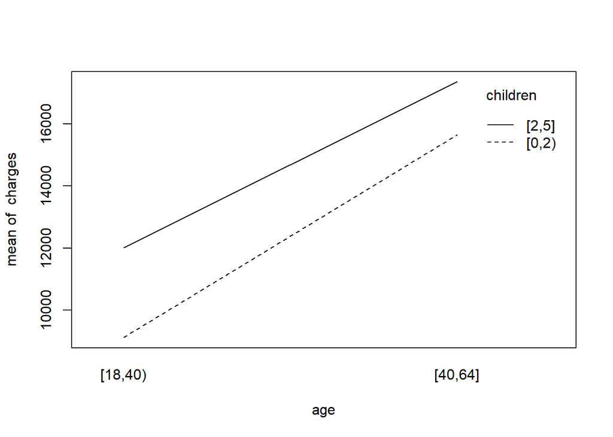

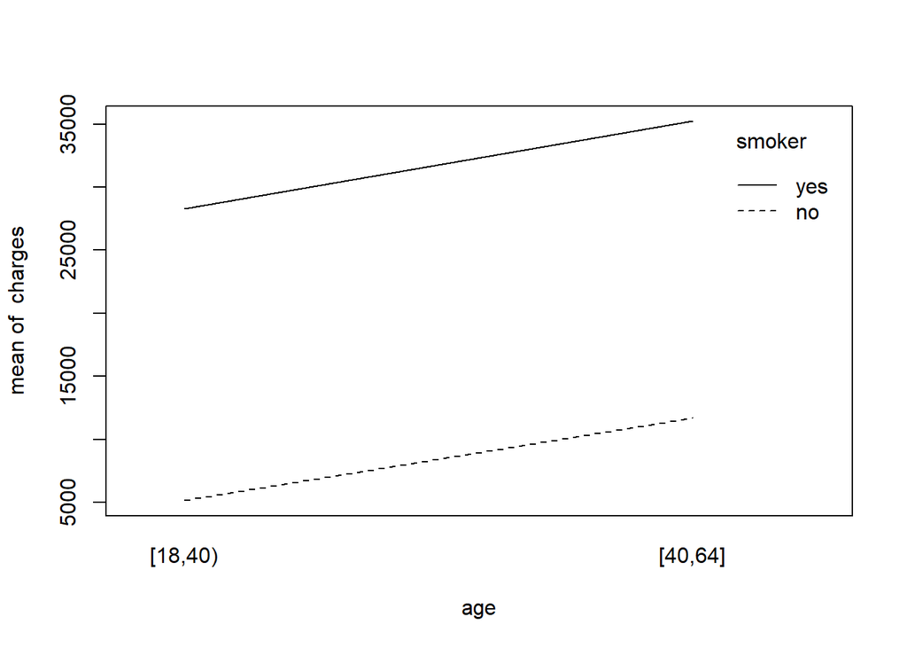

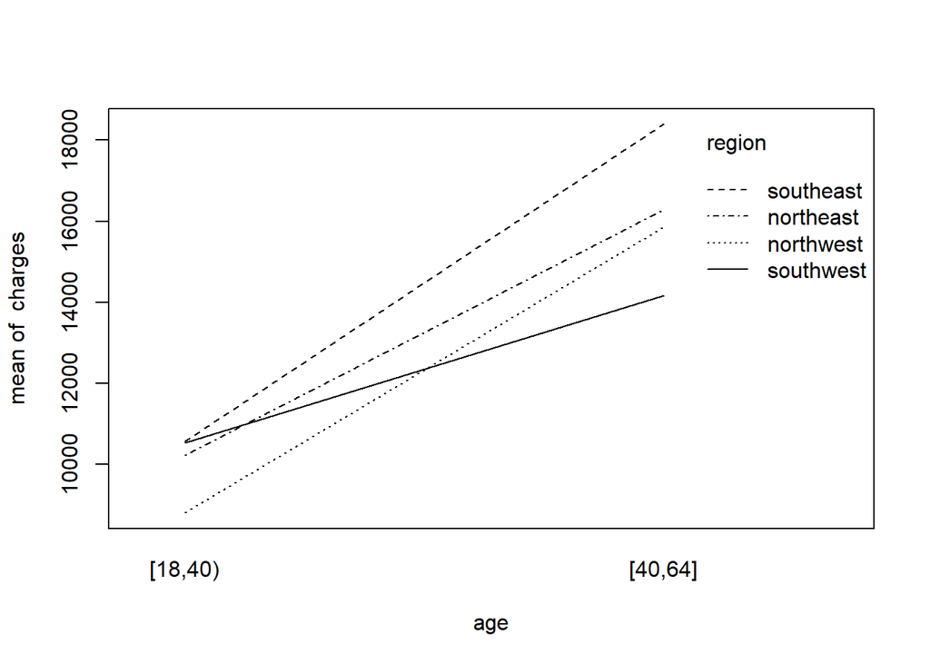

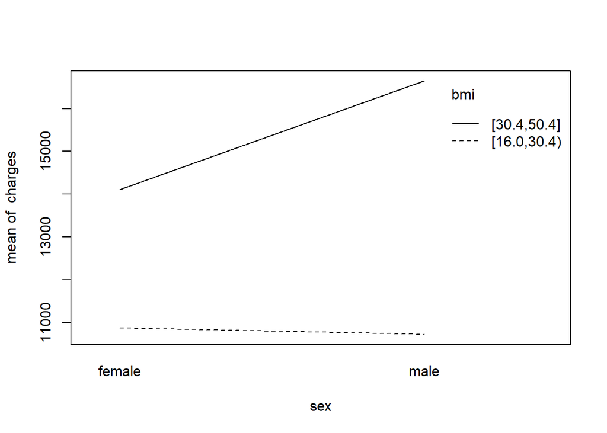

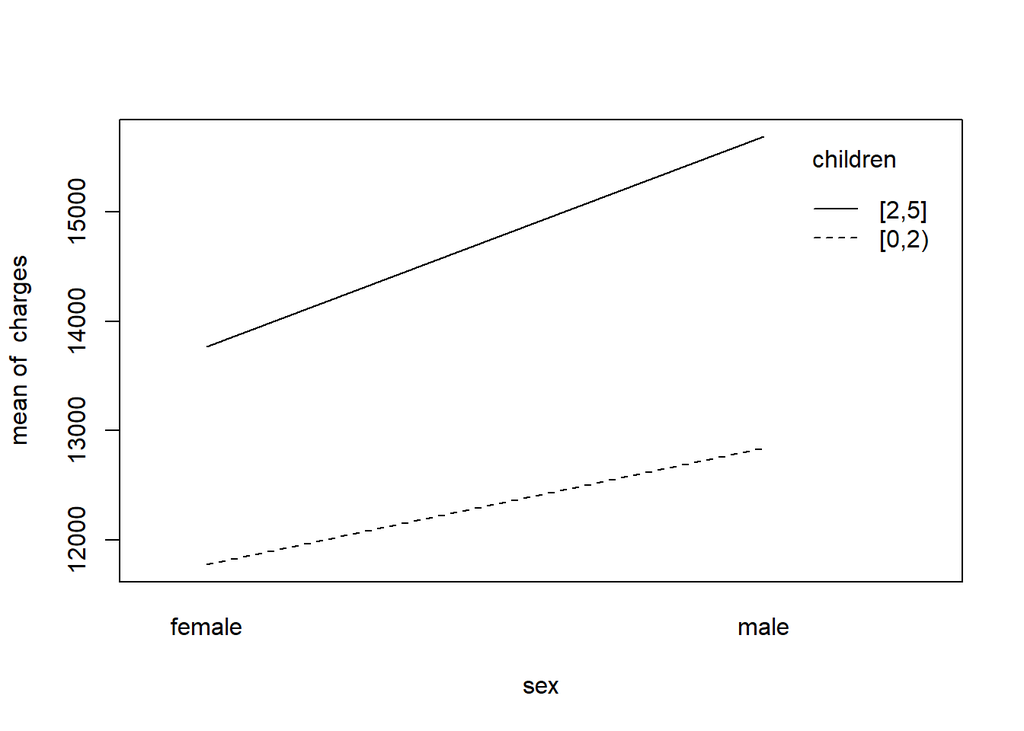

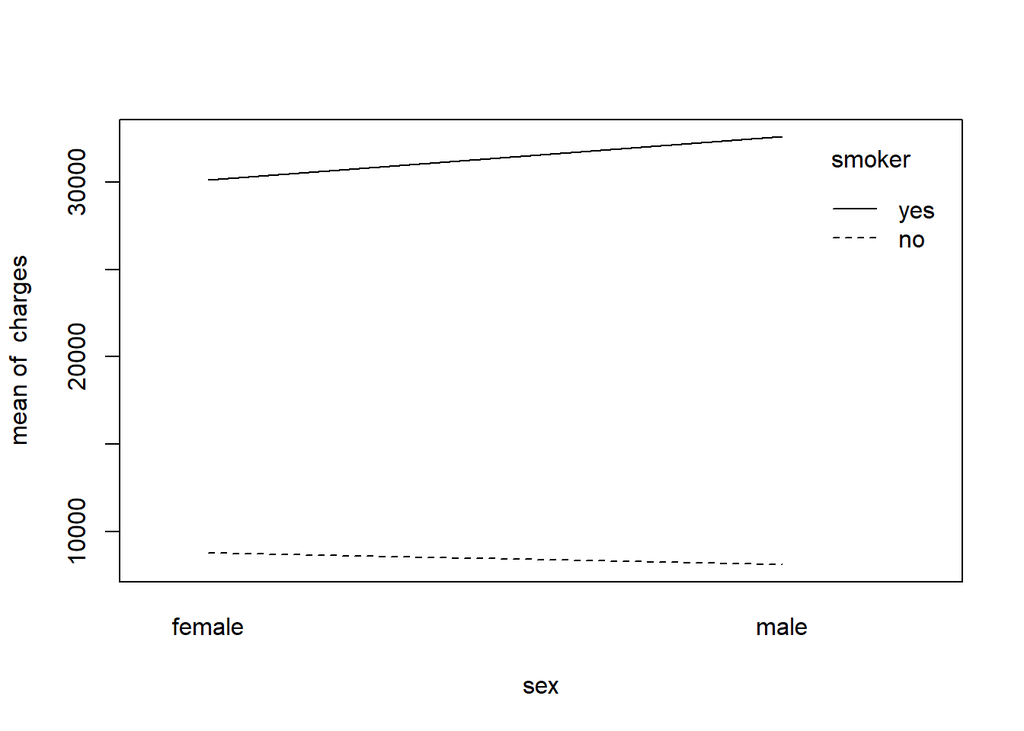

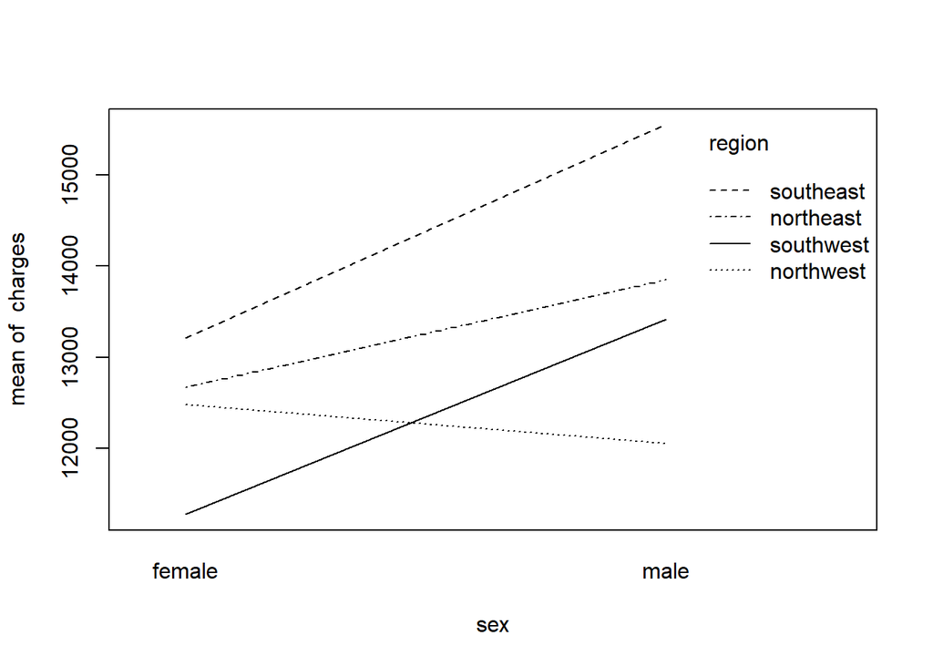

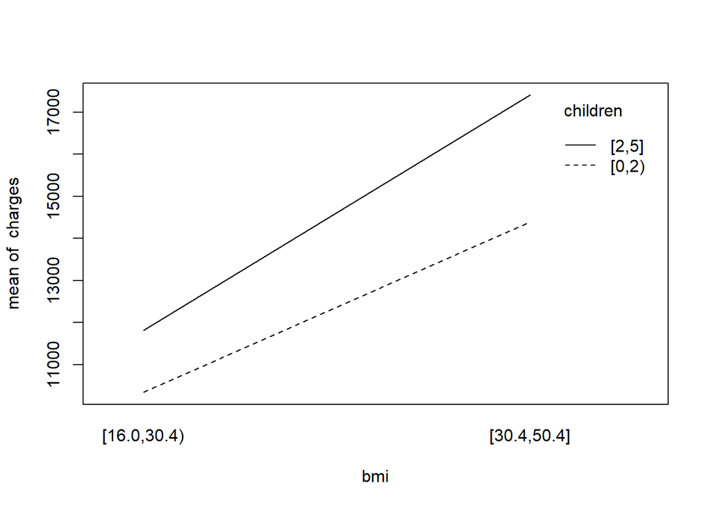

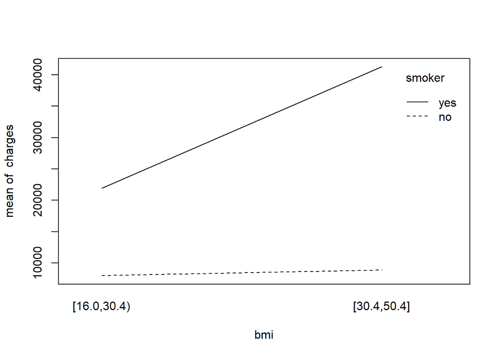

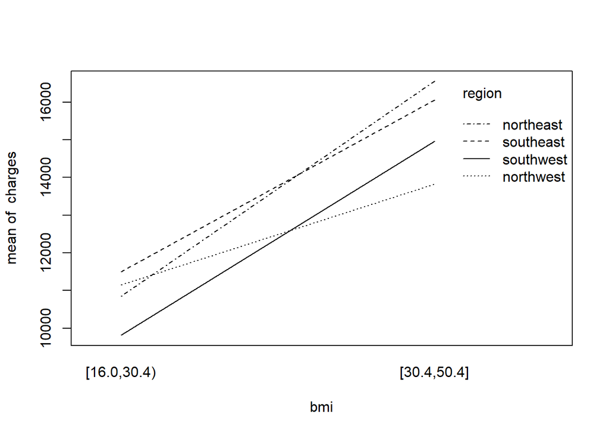

[3 more figures not shown]

```r
# Đồ thị thể hiện những tương tác hai chiều của các nhân tố
with(insurance, {
  interaction.plot(age, sex, charges)
  interaction.plot(age, bmi, charges)
  interaction.plot(age, children, charges)
  interaction.plot(age, smoker, charges)
  interaction.plot(age, region, charges)
  interaction.plot(sex, bmi, charges)
  interaction.plot(sex, children, charges)
  interaction.plot(sex, smoker, charges)
  interaction.plot(sex, region, charges)
  interaction.plot(bmi, children, charges)
  interaction.plot(bmi, smoker, charges)
  interaction.plot(bmi, region, charges)
  interaction.plot(children, smoker, charges)
  interaction.plot(children, region, charges)
  interaction.plot(smoker, region, charges)
})
```

Theo các biểu đồ interaction plot, có vẻ như không tồn tại những sự tương tác hai chiều “age” - “sex”, “age” - “bmi”, “age” - “smoker”, “sex” - “children”, “sex” - “smoker”, “children” - “smoker” (đồ thị là hai đoạn thẳng song song); và có tồn tại những sự tương tác hai chiều “age” - “children”, “sex” - “bmi”, “bmi” - “children”, “bmi” - “smoker” (đồ thị là hai đoạn thẳng hội tụ / phân kỳ) , “sex” - “region”, “age” - “region”, “bmi” - “region”, “children” - “region”, “smoker” - “region” (đồ thị là các đoạn thẳng cắt nhau). Nhận xét rằng tất cả những sự tương tác có liên quan đến nhân tố “region” có vẻ như đều tồn tại. Điều này cho thấy nhiều khả năng nhân tố “region” có ảnh hưởng lớn đến tác động của các nhân tố khác lên biến charges.

**ANOVA 6 nhân tố:**

Ta muốn đi trả lời các câu hỏi sau:

1. Có tồn tại sự khác biệt về chi phí bảo hiểm y tế giữa nhóm tuổi từ 18 đến dưới 40 và nhóm tuổi từ 40 đến 64 hay không?
2. Có tồn tại sự khác biệt về chi phí bảo hiểm y tế giữa nam và nữ hay không?
3. Có tồn tại sự khác biệt về chi phí bảo hiểm y tế giữa nhóm người có BMI từ 16 đến dưới 30.4 và nhóm người có BMI từ 30.4 đến 50.4 hay không?
4. Có tồn tại sự khác biệt về chi phí bảo hiểm y tế giữa nhóm người có 0 hoặc 1 con và nhóm người có từ 2 đến 5 con hay không?
5. Có tồn tại sự khác biệt về chi phí bảo hiểm y tế giữa những người có hút thuốc và không hút thuốc hay không?
6. Có tồn tại sự khác biệt về chi phí bảo hiểm y tế giữa những người sinh sống ở 4 vùng khác nhau hay không?
7. Tác động của độ tuổi / giới tính / chỉ số BMI / số con / tình trạng hút thuốc / vùng sinh sống lên chi phí bảo hiểm y tế có bị ảnh hưởng bởi sự kết hợp của các nhân tố còn lại hay không?

Trong đó, 6 câu hỏi đầu tiên có thể được trả lời thông qua các kiểm định tác động chính của mô hình ANOVA:

*H<sub>0</sub>: Không có tác động chính của nhân tố thứ i (trung bình tổng thể của biến phụ thuộc charges giữa các cấp độ của nhân tố thứ i là bằng nhau).*

*H<sub>1</sub>: Có tác động chính của nhân tố thứ i (trung bình tổng thể của biến phụ thuộc charges giữa các cấp độ của nhân tố thứ i có sự khác nhau).*

Và câu hỏi cuối cùng có thể được trả lời thông qua các kiểm định sự tương tác m chiều (với m = 2, 3, 4, 5, 6) của mô hình ANOVA:

*H<sub>0</sub>: Không có sự tương tác giữa m nhân tố (sự khác biệt về trung bình tổng thể của biến phụ thuộc charges giữa các cấp độ của nhân tố thứ i không phụ thuộc vào tổ hợp các cấp độ của m - 1 nhân tố còn lại, hay nói cách khác, tác động của nhân tố thứ i lên biến phụ thuộc charges không phụ thuộc vào tổ hợp các cấp độ của m - 1 nhân tố còn lại).*

*H<sub>1</sub>: Có sự tương tác giữa m nhân tố (tác động của nhân tố thứ i lên biến phụ thuộc charges phụ thuộc vào tổ hợp các cấp độ của m - 1 nhân tố còn lại)*

Ta xét mô hình ANOVA với tất cả 6 nhân tố và những sự tương tác từ 2 chiều đến 6 chiều giữa các nhân tố đó:

```r
# ANOVA 6 nhân tố
mod <- aov(charges ~ .^6, data = insurance)
# Mô hình bao gồm tất cả các nhân tố và các yếu tố tương tác từ 2 chiều đến 6 chiều giữa các nhân tố đó
summary(mod)
```

```
##                                      Df    Sum Sq   Mean Sq  F value   Pr(>F)
## age                                   1 1.271e+10 1.271e+10  533.564  < 2e-16
## sex                                   1 7.137e+08 7.137e+08   29.953 5.38e-08
## bmi                                   1 5.487e+09 5.487e+09  230.277  < 2e-16
## children                              1 1.338e+09 1.338e+09   56.167 1.29e-13
## smoker                                1 1.154e+11 1.154e+11 4844.119  < 2e-16
## region                                3 8.787e+07 2.929e+07    1.229 0.297723
## age:sex                               1 2.251e+06 2.251e+06    0.094 0.758613
## age:bmi                               1 1.771e+04 1.771e+04    0.001 0.978255
## age:children                          1 3.232e+08 3.232e+08   13.564 0.000241
## age:smoker                            1 1.973e+07 1.973e+07    0.828 0.362995
## age:region                            3 2.945e+07 9.818e+06    0.412 0.744374
## sex:bmi                               1 1.063e+08 1.063e+08    4.462 0.034870
## sex:children                          1 1.097e+05 1.097e+05    0.005 0.945908
## sex:smoker                            1 3.811e+08 3.811e+08   15.994 6.74e-05
## sex:region                            3 2.858e+07 9.527e+06    0.400 0.753126
## bmi:children                          1 1.178e+08 1.178e+08    4.943 0.026380
## bmi:smoker                            1 1.835e+10 1.835e+10  769.998  < 2e-16
## bmi:region                            3 2.291e+07 7.637e+06    0.321 0.810558
## children:smoker                       1 8.601e+07 8.601e+07    3.610 0.057686
## children:region                       3 4.980e+07 1.660e+07    0.697 0.554111
## smoker:region                         3 2.112e+08 7.041e+07    2.955 0.031543
## age:sex:bmi                           1 1.992e+07 1.992e+07    0.836 0.360663
## age:sex:children                      1 9.833e+05 9.833e+05    0.041 0.839058
## age:sex:smoker                        1 4.143e+07 4.143e+07    1.739 0.187537
## age:sex:region                        3 4.621e+07 1.540e+07    0.646 0.585275
## age:bmi:children                      1 3.337e+07 3.337e+07    1.400 0.236885
## age:bmi:smoker                        1 6.986e+06 6.986e+06    0.293 0.588268
## age:bmi:region                        3 3.352e+07 1.117e+07    0.469 0.704021
## age:children:smoker                   1 2.610e+07 2.610e+07    1.095 0.295512
## age:children:region                   3 8.755e+07 2.918e+07    1.225 0.299328
## age:smoker:region                     3 7.571e+07 2.524e+07    1.059 0.365450
## sex:bmi:children                      1 3.204e+07 3.204e+07    1.345 0.246472
## sex:bmi:smoker                        1 1.494e+07 1.494e+07    0.627 0.428600
## sex:bmi:region                        3 8.342e+07 2.781e+07    1.167 0.321099
## sex:children:smoker                   1 1.063e+07 1.063e+07    0.446 0.504302
## sex:children:region                   3 1.234e+07 4.114e+06    0.173 0.914891
## sex:smoker:region                     3 1.079e+08 3.596e+07    1.509 0.210376
## bmi:children:smoker                   1 2.912e+07 2.912e+07    1.222 0.269144
## bmi:children:region                   3 1.703e+07 5.676e+06    0.238 0.869717
```

[output cut: 77 more lines]

```
## sex:bmi:children:smoker
## sex:bmi:children:region            .
## sex:bmi:smoker:region
## sex:children:smoker:region
## bmi:children:smoker:region
## age:sex:bmi:children:smoker
## age:sex:bmi:children:region
## age:sex:bmi:smoker:region
## age:sex:children:smoker:region
## age:bmi:children:smoker:region
## sex:bmi:children:smoker:region
## age:sex:bmi:children:smoker:region
## Residuals
## ---
## Signif. codes:  0 '***' 0.001 '**' 0.01 '*' 0.05 '.' 0.1 ' ' 1
```

**Quy tắc:** (**)

Trong một mô hình ANOVA, những sự tương tác cần được kiểm định trước tiên (xét từ sự tương tác có số chiều cao nhất đến thấp nhất). Nếu một sự tương tác là có ý nghĩa thì ta không cần kiểm định tác động chính của các nhân tố trong sự tương tác đó, vì khi đó sự tác động của một nhân tố trong sự tương tác lên biến phụ thuộc sẽ bị ảnh hưởng bởi tổ hợp các cấp độ của các nhân tố còn lại trong sự tương tác. Chỉ khi một nhân tố không nằm trong bất kỳ sự tương tác có ý nghĩa nào thì ta mới cần kiểm định tác động chính của nó [1].

*Khi làm post hoc test:* Nếu một sự tương tác là có ý nghĩa thì ta chỉ cần xét sự khác biệt của trung bình biến phụ thuộc giữa các tổ hợp cấp độ của các nhân tố có trong sự tương tác đó, thay vì phải kiểm tra sự khác biệt của trung bình biến phụ thuộc giữa các cấp độ của từng nhân tố trong sự tương tác. Chỉ khi một nhân tố không nằm trong bất kỳ sự tương tác có ý nghĩa nào và tác động chính của nó là có ý nghĩa thì ta mới cần xét sự khác biệt của trung bình biến phụ thuộc giữa các cấp độ của nhân tố đó [1].

**Các kiểm định cho sự tương tác:**

Nay, ta cần đi kiểm định cho sự tương tác với số chiều lớn nhất (6 chiều) trước:

*H<sub>0</sub>: Không có sự tương tác giữa 6 nhân tố (sự khác biệt về trung bình tổng thể của biến phụ thuộc charges giữa các cấp độ của nhân tố thứ i không phụ thuộc vào tổ hợp các cấp độ của 5 nhân tố còn lại, hay nói cách khác, tác động của nhân tố thứ i lên biến phụ thuộc charges không phụ thuộc vào tổ hợp các cấp độ của 5 nhân tố còn lại).*

*H<sub>1</sub>: Có sự tương tác giữa 6 nhân tố (tác động của nhân tố thứ i lên biến phụ thuộc charges phụ thuộc vào tổ hợp các cấp độ của 5 nhân tố còn lại).*

Vì p - value = 0.9004 > 0.05 nên ta không đủ cơ sở để bác bỏ H<sub>0</sub> với mức ý nghĩa 0.05. Do đó, không có sự tương tác giữa 6 nhân tố age, sex, bmi, children, smoker, region.

Do đó, ta sẽ thử bỏ yếu tố tương tác 6 chiều không có ý nghĩa này ra khỏi mô hình:

```r
# ANOVA 6 factors after removing 6 way interaction
mod <- aov(charges ~ .^5, data = insurance)
summary(mod)
```

```
##                                  Df    Sum Sq   Mean Sq  F value   Pr(>F)
## age                               1 1.271e+10 1.271e+10  534.635  < 2e-16 ***
## sex                               1 7.137e+08 7.137e+08   30.013 5.22e-08 ***
## bmi                               1 5.487e+09 5.487e+09  230.740  < 2e-16 ***
## children                          1 1.338e+09 1.338e+09   56.280 1.22e-13 ***
## smoker                            1 1.154e+11 1.154e+11 4853.850  < 2e-16 ***
## region                            3 8.787e+07 2.929e+07    1.232 0.296826
## age:sex                           1 2.251e+06 2.251e+06    0.095 0.758378
## age:bmi                           1 1.771e+04 1.771e+04    0.001 0.978233
## age:children                      1 3.232e+08 3.232e+08   13.591 0.000237 ***
## age:smoker                        1 1.973e+07 1.973e+07    0.830 0.362513
## age:region                        3 2.945e+07 9.818e+06    0.413 0.743781
## sex:bmi                           1 1.063e+08 1.063e+08    4.471 0.034688 *
## sex:children                      1 1.097e+05 1.097e+05    0.005 0.945854
## sex:smoker                        1 3.811e+08 3.811e+08   16.027 6.63e-05 ***
## sex:region                        3 2.858e+07 9.527e+06    0.401 0.752548
## bmi:children                      1 1.178e+08 1.178e+08    4.953 0.026229 *
## bmi:smoker                        1 1.835e+10 1.835e+10  771.545  < 2e-16 ***
## bmi:region                        3 2.291e+07 7.637e+06    0.321 0.810091
## children:smoker                   1 8.601e+07 8.601e+07    3.617 0.057435 .
## children:region                   3 4.980e+07 1.660e+07    0.698 0.553260
## smoker:region                     3 2.112e+08 7.041e+07    2.961 0.031290 *
## age:sex:bmi                       1 1.992e+07 1.992e+07    0.838 0.360181
## age:sex:children                  1 9.833e+05 9.833e+05    0.041 0.838899
## age:sex:smoker                    1 4.143e+07 4.143e+07    1.742 0.187094
## age:sex:region                    3 4.621e+07 1.540e+07    0.648 0.584455
## age:bmi:children                  1 3.337e+07 3.337e+07    1.403 0.236414
## age:bmi:smoker                    1 6.986e+06 6.986e+06    0.294 0.587893
## age:bmi:region                    3 3.352e+07 1.117e+07    0.470 0.703360
## age:children:smoker               1 2.610e+07 2.610e+07    1.097 0.295028
## age:children:region               3 8.755e+07 2.918e+07    1.227 0.298430
## age:smoker:region                 3 7.571e+07 2.524e+07    1.061 0.364524
## sex:bmi:children                  1 3.204e+07 3.204e+07    1.347 0.245998
## sex:bmi:smoker                    1 1.494e+07 1.494e+07    0.628 0.428136
## sex:bmi:region                    3 8.342e+07 2.781e+07    1.169 0.320189
## sex:children:smoker               1 1.063e+07 1.063e+07    0.447 0.503874
## sex:children:region               3 1.234e+07 4.114e+06    0.173 0.914661
## sex:smoker:region                 3 1.079e+08 3.596e+07    1.512 0.209574
## bmi:children:smoker               1 2.912e+07 2.912e+07    1.225 0.268663
## bmi:children:region               3 1.703e+07 5.676e+06    0.239 0.869378
```

[output cut: 11 more lines]

```
## age:children:smoker:region        3 1.923e+07 6.409e+06    0.270 0.847402
## sex:bmi:children:smoker           1 2.203e+07 2.203e+07    0.927 0.335937
## sex:bmi:children:region           3 1.597e+08 5.324e+07    2.239 0.082077 .
## sex:bmi:smoker:region             3 9.365e+07 3.122e+07    1.313 0.268749
## sex:children:smoker:region        3 2.547e+07 8.489e+06    0.357 0.784088
## bmi:children:smoker:region        3 4.221e+06 1.407e+06    0.059 0.981128
## age:sex:bmi:children:smoker       1 3.843e+06 3.843e+06    0.162 0.687744
## age:sex:bmi:children:region       3 1.408e+07 4.693e+06    0.197 0.898214
## age:sex:bmi:smoker:region         3 8.450e+07 2.817e+07    1.185 0.314353
## age:sex:children:smoker:region    3 2.376e+07 7.920e+06    0.333 0.801431
## age:bmi:children:smoker:region    3 3.952e+07 1.317e+07    0.554 0.645528
## sex:bmi:children:smoker:region    3 6.340e+07 2.113e+07    0.889 0.446344
## Residuals                      1206 2.868e+10 2.378e+07
## ---
## Signif. codes:  0 '***' 0.001 '**' 0.01 '*' 0.05 '.' 0.1 ' ' 1
```

Sau đó, ta đi kiểm định cho 6 sự tương tác 5 chiều, với:

*H<sub>0</sub>: Không có sự tương tác giữa 5 nhân tố (sự khác biệt về trung bình tổng thể của biến phụ thuộc charges giữa các cấp độ của nhân tố thứ i không phụ thuộc vào tổ hợp các cấp độ của 4 nhân tố còn lại, hay nói cách khác, tác động của nhân tố thứ i lên biến phụ thuộc charges không phụ thuộc vào tổ hợp các cấp độ của 4 nhân tố còn lại).*

*H<sub>1</sub>: Có sự tương tác giữa 5 nhân tố (tác động của nhân tố thứ i lên biến phụ thuộc charges phụ thuộc vào tổ hợp các cấp độ của 4 nhân tố còn lại).*

1. Tương tác giữa age, sex, bmi, children, smoker:

   Vì p - value = 0.688 > 0.05 nên ta không đủ cơ sở để bác bỏ H<sub>0</sub> với mức ý nghĩa 0.05. Do đó, không có sự tương tác giữa 5 nhân tố age, sex, bmi, children, smoker.
2. Tương tác giữa age, sex, bmi, children, region:

   Vì p - value = 0.898 > 0.05 nên ta không đủ cơ sở để bác bỏ H<sub>0</sub> với mức ý nghĩa 0.05. Do đó, không có sự tương tác giữa 5 nhân tố age, sex, bmi, children, region.
3. Tương tác giữa age, sex, bmi, smoker, region:

   Vì p - value = 0.314 > 0.05 nên ta không đủ cơ sở để bác bỏ H<sub>0</sub> với mức ý nghĩa 0.05. Do đó, không có sự tương tác giữa 5 nhân tố age, sex, bmi, smoker, region.
4. Tương tác giữa age, sex, children, smoker, region:

   Vì p - value = 0.801 > 0.05 nên ta không đủ cơ sở để bác bỏ H<sub>0</sub> với mức ý nghĩa 0.05. Do đó, không có sự tương tác giữa 5 nhân tố age, sex, children, smoker, region.
5. Tương tác giữa age, bmi, children, smoker, region:

   Vì p - value = 0.646 > 0.05 nên ta không đủ cơ sở để bác bỏ H<sub>0</sub> với mức ý nghĩa 0.05. Do đó, không có sự tương tác giữa 5 nhân tố age, bmi, children, smoker, region.
6. Tương tác giữa sex, bmi, children, smoker, region:

   Vì p - value = 0.446 > 0.05 nên ta không đủ cơ sở để bác bỏ H<sub>0</sub> với mức ý nghĩa 0.05. Do đó, không có sự tương tác giữa 5 nhân tố sex, bmi, children, smoker, region.

Ta thấy cả 6 sự tương tác 5 chiều đều không có ý nghĩa. Do đó, ta sẽ loại những sự tương tác 5 chiều ra khỏi mô hình:

```r
# ANOVA 6 factors after removing 5 way and 6 way interactions
mod <- aov(charges ~ .^4, data = insurance)
summary(mod)
```

```
##                              Df    Sum Sq   Mean Sq  F value   Pr(>F)
## age                           1 1.271e+10 1.271e+10  537.435  < 2e-16 ***
## sex                           1 7.137e+08 7.137e+08   30.170 4.81e-08 ***
## bmi                           1 5.487e+09 5.487e+09  231.948  < 2e-16 ***
## children                      1 1.338e+09 1.338e+09   56.575 1.04e-13 ***
## smoker                        1 1.154e+11 1.154e+11 4879.266  < 2e-16 ***
## region                        3 8.787e+07 2.929e+07    1.238 0.294492
## age:sex                       1 2.251e+06 2.251e+06    0.095 0.757765
## age:bmi                       1 1.771e+04 1.771e+04    0.001 0.978176
## age:children                  1 3.232e+08 3.232e+08   13.663 0.000228 ***
## age:smoker                    1 1.973e+07 1.973e+07    0.834 0.361258
## age:region                    3 2.945e+07 9.818e+06    0.415 0.742231
## sex:bmi                       1 1.063e+08 1.063e+08    4.494 0.034215 *
## sex:children                  1 1.097e+05 1.097e+05    0.005 0.945712
## sex:smoker                    1 3.811e+08 3.811e+08   16.110 6.34e-05 ***
## sex:region                    3 2.858e+07 9.527e+06    0.403 0.751040
## bmi:children                  1 1.178e+08 1.178e+08    4.979 0.025838 *
## bmi:smoker                    1 1.835e+10 1.835e+10  775.585  < 2e-16 ***
## bmi:region                    3 2.291e+07 7.637e+06    0.323 0.808871
## children:smoker               1 8.601e+07 8.601e+07    3.636 0.056784 .
## children:region               3 4.980e+07 1.660e+07    0.702 0.551041
## smoker:region                 3 2.112e+08 7.041e+07    2.977 0.030636 *
## age:sex:bmi                   1 1.992e+07 1.992e+07    0.842 0.358925
## age:sex:children              1 9.833e+05 9.833e+05    0.042 0.838483
## age:sex:smoker                1 4.143e+07 4.143e+07    1.751 0.185942
## age:sex:region                3 4.621e+07 1.540e+07    0.651 0.582316
## age:bmi:children              1 3.337e+07 3.337e+07    1.411 0.235189
## age:bmi:smoker                1 6.986e+06 6.986e+06    0.295 0.586916
## age:bmi:region                3 3.352e+07 1.117e+07    0.472 0.701634
## age:children:smoker           1 2.610e+07 2.610e+07    1.103 0.293765
## age:children:region           3 8.755e+07 2.918e+07    1.234 0.296093
## age:smoker:region             3 7.571e+07 2.524e+07    1.067 0.362113
## sex:bmi:children              1 3.204e+07 3.204e+07    1.354 0.244763
## sex:bmi:smoker                1 1.494e+07 1.494e+07    0.632 0.426927
## sex:bmi:region                3 8.342e+07 2.781e+07    1.175 0.317818
## sex:children:smoker           1 1.063e+07 1.063e+07    0.449 0.502757
## sex:children:region           3 1.234e+07 4.114e+06    0.174 0.914058
## sex:smoker:region             3 1.079e+08 3.596e+07    1.520 0.207489
## bmi:children:smoker           1 2.912e+07 2.912e+07    1.231 0.267411
## bmi:children:region           3 1.703e+07 5.676e+06    0.240 0.868493
## bmi:smoker:region             3 7.002e+06 2.334e+06    0.099 0.960761
## children:smoker:region        3 2.657e+07 8.856e+06    0.374 0.771513
## age:sex:bmi:children          1 1.786e+07 1.786e+07    0.755 0.385089
## age:sex:bmi:smoker            1 3.267e+03 3.267e+03    0.000 0.990626
## age:sex:bmi:region            3 4.162e+07 1.387e+07    0.587 0.623887
## age:sex:children:smoker       1 5.466e+05 5.466e+05    0.023 0.879201
## age:sex:children:region       3 3.086e+07 1.029e+07    0.435 0.728066
## age:sex:smoker:region         3 1.170e+08 3.900e+07    1.649 0.176420
## age:bmi:children:smoker       1 2.892e+07 2.892e+07    1.222 0.269116
## age:bmi:children:region       3 2.277e+07 7.592e+06    0.321 0.810253
## age:bmi:smoker:region         3 1.011e+07 3.369e+06    0.142 0.934522
## age:children:smoker:region    3 1.923e+07 6.409e+06    0.271 0.846388
## sex:bmi:children:smoker       1 2.203e+07 2.203e+07    0.931 0.334673
## sex:bmi:children:region       3 1.597e+08 5.324e+07    2.251 0.080812 .
## sex:bmi:smoker:region         3 9.365e+07 3.122e+07    1.320 0.266474
## sex:children:smoker:region    3 2.547e+07 8.489e+06    0.359 0.782733
## bmi:children:smoker:region    3 4.221e+06 1.407e+06    0.059 0.980985
## Residuals                  1222 2.891e+10 2.366e+07
## ---
## Signif. codes:  0 '***' 0.001 '**' 0.01 '*' 0.05 '.' 0.1 ' ' 1
```

Tiếp theo, ta đi kiểm định cho 15 sự tương tác 4 chiều, với:

*H<sub>0</sub>: Không có sự tương tác giữa 4 nhân tố (sự khác biệt về trung bình tổng thể của biến phụ thuộc charges giữa các cấp độ của nhân tố thứ i không phụ thuộc vào tổ hợp các cấp độ của 3 nhân tố còn lại, hay nói cách khác, tác động của nhân tố thứ i lên biến phụ thuộc charges không phụ thuộc vào tổ hợp các cấp độ của 3 nhân tố còn lại).*

*H<sub>1</sub>: Có sự tương tác giữa 4 nhân tố (tác động của nhân tố thứ i lên biến phụ thuộc charges phụ thuộc vào tổ hợp các cấp độ của 3 nhân tố còn lại).*

1. Tương tác giữa age, sex, bmi, children:

   Vì p - value = 0.385 > 0.05 nên ta không đủ cơ sở để bác bỏ H<sub>0</sub> với mức ý nghĩa 0.05. Do đó, không có sự tương tác giữa 4 nhân tố age, sex, bmi, children.
2. Tương tác giữa age, sex, bmi, smoker:

   Vì p - value = 0.991 > 0.05 nên ta không đủ cơ sở để bác bỏ H<sub>0</sub> với mức ý nghĩa 0.05. Do đó, không có sự tương tác giữa 4 nhân tố age, sex, bmi, smoker.
3. Tương tác giữa age, sex, bmi, region:

   Vì p - value = 0.624 > 0.05 nên ta không đủ cơ sở để bác bỏ H<sub>0</sub> với mức ý nghĩa 0.05. Do đó, không có sự tương tác giữa 4 nhân tố age, sex, bmi, region.
4. Tương tác giữa age, sex, children, smoker:

   Vì p - value = 0.879 > 0.05 nên ta không đủ cơ sở để bác bỏ H<sub>0</sub> với mức ý nghĩa 0.05. Do đó, không có sự tương tác giữa 4 nhân tố age, sex, children, smoker.
5. Tương tác giữa age, sex, children, region:

   Vì p - value = 0.728 > 0.05 nên ta không đủ cơ sở để bác bỏ H<sub>0</sub> với mức ý nghĩa 0.05. Do đó, không có sự tương tác giữa 4 nhân tố age, sex, children, region.
6. Tương tác giữa age, sex, smoker, region:

   Vì p - value = 0.176 > 0.05 nên ta không đủ cơ sở để bác bỏ H<sub>0</sub> với mức ý nghĩa 0.05. Do đó, không có sự tương tác giữa 4 nhân tố age, sex, smoker, region.
7. Tương tác giữa age, bmi, children, smoker:

   mVì p - value = 0.269 > 0.05 nên ta không đủ cơ sở để bác bỏ H<sub>0</sub> với mức ý nghĩa 0.05. Do đó, không có sự tương tác giữa 4 nhân tố age, bmi, children, smoker.
8. Tương tác giữa age, bmi, children, region:

   Vì p - value = 0.810 > 0.05 nên ta không đủ cơ sở để bác bỏ H<sub>0</sub> với mức ý nghĩa 0.05. Do đó, không có sự tương tác giữa 4 nhân tố age, bmi, children, region.
9. Tương tác giữa age, bmi, smoker, region:

   Vì p - value = 0.935 > 0.05 nên ta không đủ cơ sở để bác bỏ H<sub>0</sub> với mức ý nghĩa 0.05. Do đó, không có sự tương tác giữa 4 nhân tố age, bmi, smoker, region.
10. Tương tác giữa age, children, smoker, region:

    Vì p - value = 0.846 > 0.05 nên ta không đủ cơ sở để bác bỏ H<sub>0</sub> với mức ý nghĩa 0.05. Do đó, không có sự tương tác giữa 4 nhân tố age, children, smoker, region.
11. Tương tác giữa sex, bmi, children, smoker:

    Vì p - value = 0.335 > 0.05 nên ta không đủ cơ sở để bác bỏ H<sub>0</sub> với mức ý nghĩa 0.05. Do đó, không có sự tương tác giữa 4 nhân tố sex, bmi, children, smoker.
12. Tương tác giữa sex, bmi, children, region:

    Vì p - value = 0.081 > 0.05 nên ta không đủ cơ sở để bác bỏ H<sub>0</sub> với mức ý nghĩa 0.05. Do đó, không có sự tương tác giữa 4 nhân tố sex, bmi, children, region.
13. Tương tác giữa sex, bmi, smoker, region:

    Vì p - value = 0.266 > 0.05 nên ta không đủ cơ sở để bác bỏ H<sub>0</sub> với mức ý nghĩa 0.05. Do đó, không có sự tương tác giữa 4 nhân tố sex, bmi, smoker, region.
14. Tương tác giữa sex, children, smoker, region:

    Vì p - value = 0.783 > 0.05 nên ta không đủ cơ sở để bác bỏ H<sub>0</sub> với mức ý nghĩa 0.05. Do đó, không có sự tương tác giữa 4 nhân tố sex, children, smoker, region.
15. Tương tác giữa bmi, children, smoker, region:

    Vì p - value = 0.981 > 0.05 nên ta không đủ cơ sở để bác bỏ H<sub>0</sub> với mức ý nghĩa 0.05. Do đó, không có sự tương tác giữa 4 nhân tố bmi, children, smoker, region.

Ta thấy cả 15 sự tương tác 4 chiều đều không có ý nghĩa. Do đó, ta sẽ loại những sự tương tác 4 chiều ra khỏi mô hình:

```r
# ANOVA 6 factors after removing 4 way, 5 way and 6 way interactions
mod <- aov(charges ~ .^3, data = insurance)
summary(mod)
```

```
##                          Df    Sum Sq   Mean Sq  F value   Pr(>F)
## age                       1 1.271e+10 1.271e+10  541.697  < 2e-16 ***
## sex                       1 7.137e+08 7.137e+08   30.410 4.24e-08 ***
## bmi                       1 5.487e+09 5.487e+09  233.787  < 2e-16 ***
## children                  1 1.338e+09 1.338e+09   57.023 8.25e-14 ***
## smoker                    1 1.154e+11 1.154e+11 4917.959  < 2e-16 ***
## region                    3 8.787e+07 2.929e+07    1.248 0.290965
## age:sex                   1 2.251e+06 2.251e+06    0.096 0.756835
## age:bmi                   1 1.771e+04 1.771e+04    0.001 0.978090
## age:children              1 3.232e+08 3.232e+08   13.771 0.000216 ***
## age:smoker                1 1.973e+07 1.973e+07    0.841 0.359356
## age:region                3 2.945e+07 9.818e+06    0.418 0.739875
## sex:bmi                   1 1.063e+08 1.063e+08    4.530 0.033506 *
## sex:children              1 1.097e+05 1.097e+05    0.005 0.945497
## sex:smoker                1 3.811e+08 3.811e+08   16.238 5.92e-05 ***
## sex:region                3 2.858e+07 9.527e+06    0.406 0.748745
## bmi:children              1 1.178e+08 1.178e+08    5.018 0.025252 *
## bmi:smoker                1 1.835e+10 1.835e+10  781.735  < 2e-16 ***
## bmi:region                3 2.291e+07 7.637e+06    0.325 0.807014
## children:smoker           1 8.601e+07 8.601e+07    3.665 0.055806 .
## children:region           3 4.980e+07 1.660e+07    0.707 0.547674
## smoker:region             3 2.112e+08 7.041e+07    3.000 0.029663 *
## age:sex:bmi               1 1.992e+07 1.992e+07    0.849 0.357022
## age:sex:children          1 9.833e+05 9.833e+05    0.042 0.837851
## age:sex:smoker            1 4.143e+07 4.143e+07    1.765 0.184201
## age:sex:region            3 4.621e+07 1.540e+07    0.656 0.579069
## age:bmi:children          1 3.337e+07 3.337e+07    1.422 0.233336
## age:bmi:smoker            1 6.986e+06 6.986e+06    0.298 0.585434
## age:bmi:region            3 3.352e+07 1.117e+07    0.476 0.699009
## age:children:smoker       1 2.610e+07 2.610e+07    1.112 0.291853
## age:children:region       3 8.755e+07 2.918e+07    1.243 0.292562
## age:smoker:region         3 7.571e+07 2.524e+07    1.075 0.358465
## sex:bmi:children          1 3.204e+07 3.204e+07    1.365 0.242895
## sex:bmi:smoker            1 1.494e+07 1.494e+07    0.637 0.425096
## sex:bmi:region            3 8.342e+07 2.781e+07    1.185 0.314234
## sex:children:smoker       1 1.063e+07 1.063e+07    0.453 0.501065
## sex:children:region       3 1.234e+07 4.114e+06    0.175 0.913139
## sex:smoker:region         3 1.079e+08 3.596e+07    1.532 0.204347
## bmi:children:smoker       1 2.912e+07 2.912e+07    1.241 0.265518
## bmi:children:region       3 1.703e+07 5.676e+06    0.242 0.867145
## bmi:smoker:region         3 7.002e+06 2.334e+06    0.099 0.960322
## children:smoker:region    3 2.657e+07 8.856e+06    0.377 0.769367
## Residuals              1257 2.950e+10 2.347e+07
## ---
## Signif. codes:  0 '***' 0.001 '**' 0.01 '*' 0.05 '.' 0.1 ' ' 1
```

Sau đó, ta đi kiểm định cho 20 sự tương tác 3 chiều, với:

*H<sub>0</sub>: Không có sự tương tác giữa 3 nhân tố (sự khác biệt về trung bình tổng thể của biến phụ thuộc charges giữa các cấp độ của nhân tố thứ i không phụ thuộc vào tổ hợp các cấp độ của 2 nhân tố còn lại, hay nói cách khác, tác động của nhân tố thứ i lên biến phụ thuộc charges không phụ thuộc vào tổ hợp các cấp độ của 2 nhân tố còn lại).*

*H<sub>1</sub>: Có sự tương tác giữa 3 nhân tố (tác động của nhân tố thứ i lên biến phụ thuộc charges phụ thuộc vào tổ hợp các cấp độ của 2 nhân tố còn lại).*

1. Tương tác giữa age, sex, bmi:

   Vì p - value = 0.357 > 0.05 nên ta không đủ cơ sở để bác bỏ H<sub>0</sub> với mức ý nghĩa 0.05. Do đó, không có sự tương tác giữa 3 nhân tố age, sex, bmi.
2. Tương tác giữa age, sex, children:

   Vì p - value = 0.838 > 0.05 nên ta không đủ cơ sở để bác bỏ H<sub>0</sub> với mức ý nghĩa 0.05. Do đó, không có sự tương tác giữa 3 nhân tố age, sex, children.
3. Tương tác giữa age, sex, smoker:

   Vì p - value = 0.184 > 0.05 nên ta không đủ cơ sở để bác bỏ H<sub>0</sub> với mức ý nghĩa 0.05. Do đó, không có sự tương tác giữa 3 nhân tố age, sex, smoker.
4. Tương tác giữa age, sex, region:

   Vì p - value = 0.579 > 0.05 nên ta không đủ cơ sở để bác bỏ H<sub>0</sub> với mức ý nghĩa 0.05. Do đó, không có sự tương tác giữa 3 nhân tố age, sex, region.
5. Tương tác giữa age, bmi, children:

   Vì p - value = 0.233 > 0.05 nên ta không đủ cơ sở để bác bỏ H<sub>0</sub> với mức ý nghĩa 0.05. Do đó, không có sự tương tác giữa 3 nhân tố age, bmi, children.
6. Tương tác giữa age, bmi, smoker:

   mVì p - value = 0.585 > 0.05 nên ta không đủ cơ sở để bác bỏ H<sub>0</sub> với mức ý nghĩa 0.05. Do đó, không có sự tương tác giữa 3 nhân tố age, bmi, smoker.
7. Tương tác giữa age, bmi, region:

   Vì p - value = 0.699 > 0.05 nên ta không đủ cơ sở để bác bỏ H<sub>0</sub> với mức ý nghĩa 0.05. Do đó, không có sự tương tác giữa 3 nhân tố age, bmi, region.
8. Tương tác giữa age, children, smoker:

   Vì p - value = 0.292 > 0.05 nên ta không đủ cơ sở để bác bỏ H<sub>0</sub> với mức ý nghĩa 0.05. Do đó, không có sự tương tác giữa 3 nhân tố age, children, smoker.
9. Tương tác giữa age, children, region:

   Vì p - value = 0.293 > 0.05 nên ta không đủ cơ sở để bác bỏ H<sub>0</sub> với mức ý nghĩa 0.05. Do đó, không có sự tương tác giữa 3 nhân tố age, children, region.
10. Tương tác giữa age, smoker, region:

    Vì p - value = 0.358 > 0.05 nên ta không đủ cơ sở để bác bỏ H<sub>0</sub> với mức ý nghĩa 0.05. Do đó, không có sự tương tác giữa 3 nhân tố age, smoker, region.
11. Tương tác giữa sex, bmi, children:

    Vì p - value = 0.243 > 0.05 nên ta không đủ cơ sở để bác bỏ H<sub>0</sub> với mức ý nghĩa 0.05. Do đó, không có sự tương tác giữa 3 nhân tố sex, bmi, children.
12. Tương tác giữa sex, bmi, smoker:

    Vì p - value = 0.425 > 0.05 nên ta không đủ cơ sở để bác bỏ H<sub>0</sub> với mức ý nghĩa 0.05. Do đó, không có sự tương tác giữa 3 nhân tố sex, bmi, smoker.
13. Tương tác giữa sex, bmi, region:

    Vì p - value = 0.314 > 0.05 nên ta không đủ cơ sở để bác bỏ H<sub>0</sub> với mức ý nghĩa 0.05. Do đó, không có sự tương tác giữa 3 nhân tố sex, bmi, region.
14. Tương tác giữa sex, children, smoker:

    Vì p - value = 0.501 > 0.05 nên ta không đủ cơ sở để bác bỏ H<sub>0</sub> với mức ý nghĩa 0.05. Do đó, không có sự tương tác giữa 3 nhân tố sex, children, smoker.
15. Tương tác giữa sex, children, region:

    Vì p - value = 0.913 > 0.05 nên ta không đủ cơ sở để bác bỏ H<sub>0</sub> với mức ý nghĩa 0.05. Do đó, không có sự tương tác giữa 3 nhân tố sex, children, region.
16. Tương tác giữa sex, smoker, region:

    Vì p - value = 0.204 > 0.05 nên ta không đủ cơ sở để bác bỏ H<sub>0</sub> với mức ý nghĩa 0.05. Do đó, không có sự tương tác giữa 3 nhân tố sex, smoker, region.
17. Tương tác giữa bmi, children, smoker:

    Vì p - value = 0.266 > 0.05 nên ta không đủ cơ sở để bác bỏ H<sub>0</sub> với mức ý nghĩa 0.05. Do đó, không có sự tương tác giữa 3 nhân tố bmi, children, smoker.
18. Tương tác giữa bmi, children, region

    Vì p - value = 0.867 > 0.05 nên ta không đủ cơ sở để bác bỏ H<sub>0</sub> với mức ý nghĩa 0.05. Do đó, không có sự tương tác giữa 3 nhân tố bmi, children, region.
19. Tương tác giữa bmi, smoker, region:

    Vì p - value = 0.960 > 0.05 nên ta không đủ cơ sở để bác bỏ H<sub>0</sub> với mức ý nghĩa 0.05. Do đó, không có sự tương tác giữa 3 nhân tố bmi, smoker, region.
20. Tương tác giữa children, smoker, region:

    Vì p - value = 0.769 > 0.05 nên ta không đủ cơ sở để bác bỏ H<sub>0</sub> với mức ý nghĩa 0.05. Do đó, không có sự tương tác giữa 3 nhân tố children, smoker, region.

Ta thấy cả 20 sự tương tác 3 chiều đều không có ý nghĩa. Do đó, ta sẽ loại những sự tương tác 3 chiều ra khỏi mô hình:

```r
# ANOVA 6 factors after removing 3 way, 4 way, 5 way and 6 way interactions
mod <- aov(charges ~ .^2, data = insurance)
summary(mod)
```

```
##                   Df    Sum Sq   Mean Sq  F value   Pr(>F)
## age                1 1.271e+10 1.271e+10  545.749  < 2e-16 ***
## sex                1 7.137e+08 7.137e+08   30.637 3.76e-08 ***
## bmi                1 5.487e+09 5.487e+09  235.536  < 2e-16 ***
## children           1 1.338e+09 1.338e+09   57.450 6.57e-14 ***
## smoker             1 1.154e+11 1.154e+11 4954.747  < 2e-16 ***
## region             3 8.787e+07 2.929e+07    1.257 0.287646
## age:sex            1 2.251e+06 2.251e+06    0.097 0.755955
## age:bmi            1 1.771e+04 1.771e+04    0.001 0.978008
## age:children       1 3.232e+08 3.232e+08   13.874 0.000204 ***
## age:smoker         1 1.973e+07 1.973e+07    0.847 0.357561
## age:region         3 2.945e+07 9.818e+06    0.421 0.737636
## sex:bmi            1 1.063e+08 1.063e+08    4.564 0.032846 *
## sex:children       1 1.097e+05 1.097e+05    0.005 0.945294
## sex:smoker         1 3.811e+08 3.811e+08   16.360 5.55e-05 ***
## sex:region         3 2.858e+07 9.527e+06    0.409 0.746565
## bmi:children       1 1.178e+08 1.178e+08    5.056 0.024708 *
## bmi:smoker         1 1.835e+10 1.835e+10  787.583  < 2e-16 ***
## bmi:region         3 2.291e+07 7.637e+06    0.328 0.805248
## children:smoker    1 8.601e+07 8.601e+07    3.692 0.054891 .
## children:region    3 4.980e+07 1.660e+07    0.713 0.544485
## smoker:region      3 2.112e+08 7.041e+07    3.023 0.028765 *
## Residuals       1297 3.021e+10 2.329e+07
## ---
## Signif. codes:  0 '***' 0.001 '**' 0.01 '*' 0.05 '.' 0.1 ' ' 1
```

Tiếp theo, ta đi kiểm định cho 15 sự tương tác 2 chiều, với:

*H<sub>0</sub>: Không có sự tương tác giữa 2 nhân tố (sự khác biệt về trung bình tổng thể của biến phụ thuộc charges giữa các cấp độ của nhân tố thứ i không phụ thuộc vào cấp độ của nhân tố còn lại, hay nói cách khác, tác động của nhân tố thứ i lên biến phụ thuộc charges không phụ thuộc vào cấp độ của nhân tố còn lại).*

*H<sub>1</sub>: Có sự tương tác giữa 2 nhân tố (tác động của nhân tố thứ i lên biến phụ thuộc charges phụ thuộc vào cấp độ của nhân tố còn lại).*

1. Tương tác giữa age, sex:

   Vì p - value = 0.756 > 0.05 nên ta không đủ cơ sở để bác bỏ H<sub>0</sub> với mức ý nghĩa 0.05. Do đó, không có sự tương tác giữa 2 nhân tố age, sex.
2. Tương tác giữa age, bmi

   Vì p - value = 0.978 > 0.05 nên ta không đủ cơ sở để bác bỏ H<sub>0</sub> với mức ý nghĩa 0.05. Do đó, không có sự tương tác giữa 2 nhân tố age, bmi.
3. Tương tác giữa age, children:

   Vì p - value = 0.0002 < 0.05 nên ta bác bỏ H<sub>0</sub> với mức ý nghĩa 0.05. Do đó, có tồn tại sự tương tác giữa 2 nhân tố age, children.
4. Tương tác giữa age, smoker:

   Vì p - value = 0.358 > 0.05 nên ta không đủ cơ sở để bác bỏ H<sub>0</sub> với mức ý nghĩa 0.05. Do đó, không có sự tương tác giữa 2 nhân tố age, smoker.
5. Tương tác giữa age, region:

   Vì p - value = 0.738 > 0.05 nên ta không đủ cơ sở để bác bỏ H<sub>0</sub> với mức ý nghĩa 0.05. Do đó, không có sự tương tác giữa 2 nhân tố age, region.
6. Tương tác giữa sex, bmi:

   Vì p - value = 0.033 < 0.05 nên ta bác bỏ H<sub>0</sub> với mức ý nghĩa 0.05. Do đó, có tồn tại sự tương tác giữa 2 nhân tố sex, bmi.
7. Tương tác giữa sex, children:

   Vì p - value = 0.945 > 0.05 nên ta không đủ cơ sở để bác bỏ H<sub>0</sub> với mức ý nghĩa 0.05. Do đó, không có sự tương tác giữa 2 nhân tố sex, children.
8. Tương tác giữa sex, smoker:

   Vì p - value = 5.55 x 10<sup>-5</sup> < 0.05 nên ta bác bỏ H<sub>0</sub> với mức ý nghĩa 0.05. Do đó, có tồn tại sự tương tác giữa 2 nhân tố sex, smoker.
9. Tương tác giữa sex, region:

   Vì p - value = 0.747 > 0.05 nên ta không đủ cơ sở để bác bỏ H<sub>0</sub> với mức ý nghĩa 0.05. Do đó, không có sự tương tác giữa 2 nhân tố sex, region.
10. Tương tác giữa bmi, children:

    Vì p - value = 0.025 < 0.05 nên ta bác bỏ H<sub>0</sub> với mức ý nghĩa 0.05. Do đó, có tồn tại sự tương tác giữa 2 nhân tố bmi, children.
11. Tương tác giữa bmi, smoker:

    Vì p - value < 2 x 10<sup>-16</sup> < 0.05 nên ta bác bỏ H<sub>0</sub> với mức ý nghĩa 0.05. Do đó, có tồn tại sự tương tác giữa 2 nhân tố bmi, smoker.
12. Tương tác giữa bmi, region:

    Vì p - value = 0.805 > 0.05 nên ta không đủ cơ sở để bác bỏ H<sub>0</sub> với mức ý nghĩa 0.05. Do đó, không có sự tương tác giữa 2 nhân tố bmi, region.
13. Tương tác giữa children, smoker:

    Vì p - value = 0.029 < 0.05 nên ta bác bỏ H<sub>0</sub> với mức ý nghĩa 0.05. Do đó, có tồn tại sự tương tác giữa 2 nhân tố smoker, region.

```r
# ANOVA 6 factors after removing some 2 way and all 3 way, 4 way, 5 way and 6 way interactions
mod_aov <- aov(charges ~ . + age:children + sex:bmi + sex:smoker + bmi:children + bmi:smoker + children:smoker + smoker:region, data = insurance)
summary(mod_aov)
```

```
##                   Df    Sum Sq   Mean Sq  F value   Pr(>F)
## age                1 1.271e+10 1.271e+10  550.095  < 2e-16 ***
## sex                1 7.137e+08 7.137e+08   30.881 3.32e-08 ***
## bmi                1 5.487e+09 5.487e+09  237.412  < 2e-16 ***
## children           1 1.338e+09 1.338e+09   57.907 5.22e-14 ***
## smoker             1 1.154e+11 1.154e+11 4994.206  < 2e-16 ***
## region             3 8.787e+07 2.929e+07    1.267 0.284133
## age:children       1 3.234e+08 3.234e+08   13.994 0.000191 ***
## sex:bmi            1 1.014e+08 1.014e+08    4.389 0.036366 *
## sex:smoker         1 3.790e+08 3.790e+08   16.401 5.43e-05 ***
## bmi:children       1 1.051e+08 1.051e+08    4.548 0.033149 *
## bmi:smoker         1 1.839e+10 1.839e+10  795.708  < 2e-16 ***
## children:smoker    1 9.155e+07 9.155e+07    3.961 0.046765 *
## smoker:region      3 2.041e+08 6.802e+07    2.943 0.032024 *
## Residuals       1313 3.034e+10 2.311e+07
## ---
## Signif. codes:  0 '***' 0.001 '**' 0.01 '*' 0.05 '.' 0.1 ' ' 1
```

**Các kiểm định cho tác động chính:**

Theo Quy tắc (**), vì cả 6 nhân tố đều nằm trong ít nhất một sự tương tác 2 chiều có ý nghĩa nên ta không cần kiểm định tác động chính của từng nhân tố.

### Post hoc test:

Kết quả ANOVA không chỉ ra rằng trung bình biến charges khác nhau giữa các nhóm nào của thiết kế thí nghiệm. Và để kiểm tra điều này, ở đây ta sẽ sử dụng post hoc test Tukey’s HSD.

Vì cả 6 nhân tố đều nằm trong ít nhất một sự tương tác 2 chiều có ý nghĩa nên theo Quy tắc (**), thay vì đi kiểm tra sự khác biệt của trung bình biến charges giữa các cấp độ của từng nhân tố:

```r
## Tukey's HSD để kiểm tra sự khác biệt của trung bình biến charges giữa các cấp độ của từng nhân tố (không cần làm)
# TukeyHSD(mod, which = 'age', conf.level=.95, console=TRUE)
# TukeyHSD(mod, which = 'sex', conf.level=.95, console=TRUE)
# TukeyHSD(mod, which = 'bmi', conf.level=.95, console=TRUE)
# TukeyHSD(mod, which = 'children', conf.level=.95, console=TRUE)
# TukeyHSD(mod, which = 'smoker', conf.level=.95, console=TRUE)
# TukeyHSD(mod, which = 'region', conf.level=.95, console=TRUE)
```

thì ta đi xét sự khác biệt của trung bình biến phụ thuộc giữa các tổ hợp cấp độ của các nhân tố có trong từng sự tương tác:

Xét sự tương tác 2 chiều giữa 2 nhân tố A và B. Gọi (i, j) là nhóm gồm cấp độ i của nhân tố A và cấp độ j của nhân tố B; (h, l) là nhóm gồm cấp độ h của nhân tố A và cấp độ l của nhân tố B, với $(i,j) \neq (h,l)$ *.* Kiểm định Tukey’s HSD cho sự khác biệt của trung bình biến charges giữa nhóm (i, j) và nhóm (h, l) có:

*H<sub>0</sub> : Không có sự khác biệt về trung bình của biến charges giữa nhóm (i, j) và nhóm (h, l).*

*H<sub>1</sub> : Có sự khác biệt về trung bình của biến charges giữa nhóm (i, j) và nhóm (h, l).*

Đồng thời, nhìn vào cột diff của kết quả hàm TukeyHSD(), nếu tại dòng (i : j) - (h : l) có giá trị là dương thì tức là trung bình biến charges ứng với nhóm (i : j) sẽ cao hơn là ứng với nhóm (h : l) và ngược lại.

```r
## Tukey's HSD để xét sự khác biệt của trung bình biến phụ thuộc giữa các tổ hợp cấp độ của các nhân tố có trong từng sự tương tác
TukeyHSD(mod_aov, which = 'age:children', conf.level=.95, console=TRUE)
```

```
##   Tukey multiple comparisons of means
##     95% family-wise confidence level
##
## Fit: aov(formula = charges ~ . + age:children + sex:bmi + sex:smoker + bmi:children + bmi:smoker + children:smoker + smoker:region, data = insurance)
##
## $`age:children`
##                                  diff         lwr       upr     p adj
## [40,64]:[0,2)-[18,40):[0,2)  6827.919  6000.05886  7655.779 0.0000000
## [18,40):[2,5]-[18,40):[0,2)  3189.858  2165.55377  4214.162 0.0000000
## [40,64]:[2,5]-[18,40):[0,2)  7920.271  6911.65961  8928.883 0.0000000
## [18,40):[2,5]-[40,64]:[0,2) -3638.061 -4670.20243 -2605.920 0.0000000
## [40,64]:[2,5]-[40,64]:[0,2)  1092.352    75.78243  2108.922 0.0295089
## [40,64]:[2,5]-[18,40):[2,5]  4730.414  3548.35584  5912.471 0.0000000
```

Xét sự tương tác 2 chiều giữa “age” và “children”:

- Khi i = [40,64], j = [0,2), h = [18,40), l =0,2):

  Vì p - value = 0 < 0.05 nên ta bác bỏ H<sub>0</sub> với mức ý nghĩa 0.05. Và ta kết luận rằng có sự khác biệt về trung bình của biến charges giữa nhóm (i, j) và nhóm (h, l). Cụ thể, trung bình biến charges ứng với nhóm (i, j) cao hơn là ứng với nhóm (h, l).
- Khi i = [18,40), j = [2,5], h = [18,40), l =0,2):

  Vì p - value = 0 < 0.05 nên ta bác bỏ H<sub>0</sub> với mức ý nghĩa 0.05. Và ta kết luận rằng có sự khác biệt về trung bình của biến charges giữa nhóm (i, j) và nhóm (h, l). Cụ thể, trung bình biến charges ứng với nhóm (i, j) cao hơn là ứng với nhóm (h, l).
- Khi i = [40,64), j = [2,5], h = [18,40), l =0,2):

  Vì p - value = 0 < 0.05 nên ta bác bỏ H<sub>0</sub> với mức ý nghĩa 0.05. Và ta kết luận rằng có sự khác biệt về trung bình của biến charges giữa nhóm (i, j) và nhóm (h, l). Cụ thể, trung bình biến charges ứng với nhóm (i, j) cao hơn là ứng với nhóm (h, l).
- Khi i = [18,40), j = [2,5], h = [40,64], l =0,2):

  Vì p - value = 0 < 0.05 nên ta bác bỏ H<sub>0</sub> với mức ý nghĩa 0.05. Và ta kết luận rằng có sự khác biệt về trung bình của biến charges giữa nhóm (i, j) và nhóm (h, l). Cụ thể, trung bình biến charges ứng với nhóm (i, j) thấp hơn là ứng với nhóm (h, l).
- Khi i = [40,64], j = [2,5], h = [40,64], l = 0,2):

  Vì p - value = 0.030 < 0.05 nên ta bác bỏ H<sub>0</sub> với mức ý nghĩa 0.05. Và ta kết luận rằng có sự khác biệt về trung bình của biến charges giữa nhóm (i, j) và nhóm (h, l). Cụ thể, trung bình biến charges ứng với nhóm (i, j) cao hơn là ứng với nhóm (h, l).
- Khi i = [40,64), j = [2,5], h = [18,40), l =2,5):

  Vì p - value = 0 < 0.05 nên ta bác bỏ H<sub>0</sub> với mức ý nghĩa 0.05. Và ta kết luận rằng có sự khác biệt về trung bình của biến charges giữa nhóm (i, j) và nhóm (h, l). Cụ thể, trung bình biến charges ứng với nhóm (i, j) cao hơn là ứng với nhóm (h, l).

Như vậy, có sự khác biệt về trung bình biến charges giữa tất cả các tổ hợp cấp độ của hai nhân tố “age” và “children”.

```r
TukeyHSD(mod_aov, which = 'sex:bmi', conf.level=.95, console=TRUE)
```

```
##   Tukey multiple comparisons of means
##     95% family-wise confidence level
##
## Fit: aov(formula = charges ~ . + age:children + sex:bmi + sex:smoker + bmi:children + bmi:smoker + children:smoker + smoker:region, data = insurance)
##
## $`sex:bmi`
##                                            diff       lwr      upr     p adj
## male:[16.0,30.4)-female:[16.0,30.4)    755.6654 -202.3575 1713.688 0.1778203
## female:[30.4,50.4]-female:[16.0,30.4) 3489.6080 2525.3691 4453.847 0.0000000
## male:[30.4,50.4]-female:[16.0,30.4)   5355.4981 4414.6167 6296.380 0.0000000
## female:[30.4,50.4]-male:[16.0,30.4)   2733.9426 1756.2406 3711.645 0.0000000
## male:[30.4,50.4]-male:[16.0,30.4)     4599.8327 3645.1588 5554.507 0.0000000
## male:[30.4,50.4]-female:[30.4,50.4]   1865.8901  904.9785 2826.802 0.0000040
```

Xét sự tương tác 2 chiều giữa “sex” và “bmi”:

Làm tương tự như trên, ta được kết quả là:

Có sự khác biệt về trung bình biến charges giữa tất cả các tổ hợp cấp độ của hai nhân tố “sex” và “bmi”, ngoại trừ giữa tổ hợp (sex = male, bmi = [16.0, 30.4)) và tổ hợp (sex = female, bmi = [16.0, 30.4)).

```r
TukeyHSD(mod_aov, which = 'sex:smoker', conf.level=.95, console=TRUE)
```

```
##   Tukey multiple comparisons of means
##     95% family-wise confidence level
##
## Fit: aov(formula = charges ~ . + age:children + sex:bmi + sex:smoker + bmi:children + bmi:smoker + children:smoker + smoker:region, data = insurance)
##
## $`sex:smoker`
##                            diff       lwr       upr     p adj
## male:no-female:no     -467.5035 -1226.734   291.727 0.3881431
## female:yes-female:no 21756.3524 20478.326 23034.378 0.0000000
## male:yes-female:no   23924.8537 22802.209 25047.499 0.0000000
## female:yes-male:no   22223.8559 20939.475 23508.237 0.0000000
## male:yes-male:no     24392.3572 23262.483 25522.231 0.0000000
## male:yes-female:yes   2168.5013   640.910  3696.093 0.0015426
```

Xét sự tương tác 2 chiều giữa “sex” và “smoker”:

Làm tương tự như trên, ta được kết quả là:

Có sự khác biệt về trung bình biến charges giữa tất cả các tổ hợp cấp độ của hai nhân tố “sex” và “smoker”, ngoại trừ giữa tổ hợp (sex = male, smoker = no) và tổ hợp (sex = female, smoker = no).

```r
TukeyHSD(mod_aov, which = 'bmi:children', conf.level=.95, console=TRUE)
```

```
##   Tukey multiple comparisons of means
##     95% family-wise confidence level
##
## Fit: aov(formula = charges ~ . + age:children + sex:bmi + sex:smoker + bmi:children + bmi:smoker + children:smoker + smoker:region, data = insurance)
##
## $`bmi:children`
##                                          diff        lwr       upr     p adj
## [30.4,50.4]:[0,2)-[16.0,30.4):[0,2)  3579.237  2751.2818  4407.193 0.0000000
## [16.0,30.4):[2,5]-[16.0,30.4):[0,2)  1519.467   485.8555  2553.079 0.0009358
## [30.4,50.4]:[2,5]-[16.0,30.4):[0,2)  6284.026  5285.0108  7283.040 0.0000000
## [16.0,30.4):[2,5]-[30.4,50.4]:[0,2) -2059.770 -3102.6243 -1016.916 0.0000026
## [30.4,50.4]:[2,5]-[30.4,50.4]:[0,2)  2704.788  1696.2140  3713.362 0.0000000
## [30.4,50.4]:[2,5]-[16.0,30.4):[2,5]  4764.558  3581.3151  5947.802 0.0000000
```

Xét sự tương tác 2 chiều giữa “bmi” và “children”:

Làm tương tự như trên, ta được kết quả là:

Có sự khác biệt về trung bình biến charges giữa tất cả các tổ hợp cấp độ của hai nhân tố “bmi” và “children”.

```r
TukeyHSD(mod_aov, which = 'bmi:smoker', conf.level=.95, console=TRUE)
```

```
##   Tukey multiple comparisons of means
##     95% family-wise confidence level
##
## Fit: aov(formula = charges ~ . + age:children + sex:bmi + sex:smoker + bmi:children + bmi:smoker + children:smoker + smoker:region, data = insurance)
##
## $`bmi:smoker`
##                                       diff        lwr       upr     p adj
## [30.4,50.4]:no-[16.0,30.4):no     404.8897  -354.0391  1163.819 0.5169865
## [16.0,30.4):yes-[16.0,30.4):no  14096.7806 12905.0646 15288.497 0.0000000
## [30.4,50.4]:yes-[16.0,30.4):no  32567.1760 31371.9186 33762.433 0.0000000
## [16.0,30.4):yes-[30.4,50.4]:no  13691.8909 12499.7199 14884.062 0.0000000
## [30.4,50.4]:yes-[30.4,50.4]:no  32162.2863 30966.5752 33357.997 0.0000000
## [30.4,50.4]:yes-[16.0,30.4):yes 18470.3955 16962.4369 19978.354 0.0000000
```

Xét sự tương tác 2 chiều giữa “bmi” và “smoker”:

Làm tương tự như trên, ta được kết quả là:

Có sự khác biệt về trung bình biến charges giữa tất cả các tổ hợp cấp độ của hai nhân tố “bmi” và “smoker”, ngoại trừ giữa tổ hợp (bmi = [30.4, 50.4], smoker = no) và tổ hợp (bmi = [16.0, 30.4), smoker = no).

```r
TukeyHSD(mod_aov, which = 'children:smoker', conf.level=.95, console=TRUE)
```

```
##   Tukey multiple comparisons of means
##     95% family-wise confidence level
##
## Fit: aov(formula = charges ~ . + age:children + sex:bmi + sex:smoker + bmi:children + bmi:smoker + children:smoker + smoker:region, data = insurance)
##
## $`children:smoker`
##                           diff        lwr       upr     p adj
## [2,5]:no-[0,2):no    1768.5508   955.8139  2581.288 0.0000002
## [0,2):yes-[0,2):no  23636.5507 22587.1861 24685.915 0.0000000
## [2,5]:yes-[0,2):no  23967.5231 22630.1404 25304.906 0.0000000
## [0,2):yes-[2,5]:no  21868.0000 20711.4888 23024.511 0.0000000
## [2,5]:yes-[2,5]:no  22198.9724 20775.9669 23621.978 0.0000000
## [2,5]:yes-[0,2):yes   330.9724 -1239.2407  1901.186 0.9486409
```

Xét sự tương tác 2 chiều giữa “children” và “smoker”:

Làm tương tự như trên, ta được kết quả là:

Có sự khác biệt về trung bình biến charges giữa tất cả các tổ hợp cấp độ của hai nhân tố “children” và “smoker”, ngoại trừ giữa tổ hợp (children = [2, 5], smoker = yes) và tổ hợp (children = [0, 2), smoker = yes).

```r
TukeyHSD(mod_aov, which = 'smoker:region', conf.level=.95, console=TRUE)
```

```
##   Tukey multiple comparisons of means
##     95% family-wise confidence level
##
## Fit: aov(formula = charges ~ . + age:children + sex:bmi + sex:smoker + bmi:children + bmi:smoker + children:smoker + smoker:region, data = insurance)
##
## $`smoker:region`
##                                     diff        lwr         upr     p adj
## yes:northeast-no:northeast   21590.13775  19576.218  23604.0574 0.0000000
## no:northwest-no:northeast     -765.08905  -2040.420    510.2418 0.6056410
## yes:northwest-no:northeast   22872.77959  20736.096  25009.4634 0.0000000
## no:southeast-no:northeast     -980.98122  -2251.687    289.7250 0.2707201
## yes:southeast-no:northeast   22297.56397  20495.040  24100.0880 0.0000000
## no:southwest-no:northeast    -1104.80190  -2380.133    170.5290 0.1461223
## yes:southwest-no:northeast   22936.08531  20814.531  25057.6395 0.0000000
## no:northwest-yes:northeast  -22355.22680 -24361.425 -20349.0282 0.0000000
## yes:northwest-yes:northeast   1282.64184  -1356.256   3921.5397 0.8205451
## no:southeast-yes:northeast  -22571.11897 -24574.381 -20567.8570 0.0000000
## yes:southeast-yes:northeast    707.42622  -1669.012   3083.8641 0.9857533
## no:southwest-yes:northeast  -22694.93965 -24701.138 -20688.7410 0.0000000
## yes:southwest-yes:northeast   1345.94756  -1280.715   3972.6102 0.7766714
## yes:northwest-no:northwest   23637.86864  21508.461  25767.2765 0.0000000
## no:southeast-no:northwest     -215.89218  -1474.326   1042.5413 0.9995578
## yes:southeast-no:northwest   23062.65302  21268.760  24856.5464 0.0000000
## no:southwest-no:northwest     -339.71285  -1602.816    923.3902 0.9922278
## yes:southwest-no:northwest   23701.17435  21586.948  25815.4006 0.0000000
## no:southeast-yes:northwest  -23853.76082 -25980.402 -21727.1194 0.0000000
## yes:southeast-yes:northwest   -575.21562  -3056.546   1906.1151 0.9969005
## no:southwest-yes:northwest  -23977.58149 -26106.989 -21848.1736 0.0000000
## yes:southwest-yes:northwest     63.30571  -2658.624   2785.2354 1.0000000
## yes:southeast-no:southeast   23278.54520  21487.937  25069.1538 0.0000000
## no:southwest-no:southeast     -123.82067  -1382.254   1134.6128 0.9999897
## yes:southwest-no:southeast   23917.06653  21805.627  26028.5064 0.0000000
## no:southwest-yes:southeast  -23402.36587 -25196.259 -21608.4725 0.0000000
## yes:southwest-yes:southeast    638.52133  -1829.793   3106.8359 0.9938700
## yes:southwest-no:southwest   24040.88720  21926.661  26155.1135 0.0000000
```

Xét sự tương tác 2 chiều giữa “smoker” và “region”:

Làm tương tự như trên, ta được kết quả là:

Có sự khác biệt về trung bình biến charges giữa:

1. Tổ hợp (smoker = yes, region = northeast) và tổ hợp (smoker = no, region = northeast).
2. Tổ hợp (smoker = yes, region = northwest) và tổ hợp (smoker = no, region = northeast).
3. Tổ hợp (smoker = yes, region = southeast) và tổ hợp (smoker = no, region = northeast).
4. Tổ hợp (smoker = yes, region = southwest) và tổ hợp (smoker = no, region = northeast).
5. Tổ hợp (smoker = no, region = northwest) và tổ hợp (smoker = yes, region = northeast).
6. Tổ hợp (smoker = no, region = southeast) và tổ hợp (smoker = yes, region = northeast).
7. Tổ hợp (smoker = no, region = southwest) và tổ hợp (smoker = yes, region = northeast).
8. Tổ hợp (smoker = yes, region = northwest) và tổ hợp (smoker = no, region = northwest).
9. Tổ hợp (smoker = yes, region = southeast) và tổ hợp (smoker = no, region = northwest).
10. Tổ hợp (smoker = yes, region = southwest) và tổ hợp (smoker = no, region = northwest).
11. Tổ hợp (smoker = no, region = southeast) và tổ hợp (smoker = yes, region = northwest).
12. Tổ hợp (smoker = no, region = southwest) và tổ hợp (smoker = yes, region = northwest).
13. Tổ hợp (smoker = yes, region = southeast) và tổ hợp (smoker = no, region = southeast).
14. Tổ hợp (smoker = yes, region = southwest) và tổ hợp (smoker = no, region = southeast).
15. Tổ hợp (smoker = no, region = southwest) và tổ hợp (smoker = yes, region = southeast).
16. Tổ hợp (smoker = yes, region = southwest) và tổ hợp (smoker = no, region = southwest).

Nhìn chung, có sự khác biệt về trung bình biến charges giữa hầu hết các tổ hợp cấp độ của hai nhân tố “smoker” và “region”.

**Nhận xét:**

- Chi phí bảo hiểm y tế của một người có sự khác biệt giữa mọi tổ hợp cấp độ của độ tuổi và số con của người đó.
- Chi phí bảo hiểm y tế của một người có sự khác biệt giữa mọi tổ hợp cấp độ của giới tính và chỉ số BMI của người đó, ngoại từ giữa tổ hợp “nam với chỉ số BMI từ 16 đến dưới 30.4” và tổ hợp “nữ với chỉ số BMI từ 16 đến dưới 30.4”.
- Chi phí bảo hiểm y tế của một người có sự khác biệt giữa mọi tổ hợp cấp độ của giới tính và tình trạng hút thuốc của người đó, ngoại từ giữa tổ hợp “nam không hút thuốc” và tổ hợp “nữ không hút thuốc”.
- Chi phí bảo hiểm y tế của một người có sự khác biệt giữa mọi tổ hợp cấp độ của chỉ số BMI và số con của người đó.
- Chi phí bảo hiểm y tế của một người có sự khác biệt giữa mọi tổ hợp cấp độ của chỉ số BMI và tình trạng hút thuốc của người đó, ngoại từ giữa tổ hợp “người có chỉ số BMI từ 30.4 đến 50.4 và không hút thuốc” và tổ hợp “người có chỉ số BMI từ 16 đến dưới 30.4 và không hút thuốc”.
- Chi phí bảo hiểm y tế của một người có sự khác biệt giữa mọi tổ hợp cấp độ của số con và tình trạng hút thuốc của người đó, ngoại từ giữa tổ hợp “người có từ 2 đến 5 con và có hút thuốc” và tổ hợp “người không có con hoặc có 1 con và có hút thuốc”.
- Chi phí bảo hiểm y tế của một người có sự khác biệt giữa hầu hết các tổ hợp cấp độ của tình trạng hút thuốc và vùng sinh sống của người đó.

### (c) Đưa ra mô hình được xét và kiểm tra các giả định của mô hình:

Mô hình mà ta xét là mô hình mod_aov:

```r
summary(mod_aov)
```

```
##                   Df    Sum Sq   Mean Sq  F value   Pr(>F)
## age                1 1.271e+10 1.271e+10  550.095  < 2e-16 ***
## sex                1 7.137e+08 7.137e+08   30.881 3.32e-08 ***
## bmi                1 5.487e+09 5.487e+09  237.412  < 2e-16 ***
## children           1 1.338e+09 1.338e+09   57.907 5.22e-14 ***
## smoker             1 1.154e+11 1.154e+11 4994.206  < 2e-16 ***
## region             3 8.787e+07 2.929e+07    1.267 0.284133
## age:children       1 3.234e+08 3.234e+08   13.994 0.000191 ***
## sex:bmi            1 1.014e+08 1.014e+08    4.389 0.036366 *
## sex:smoker         1 3.790e+08 3.790e+08   16.401 5.43e-05 ***
## bmi:children       1 1.051e+08 1.051e+08    4.548 0.033149 *
## bmi:smoker         1 1.839e+10 1.839e+10  795.708  < 2e-16 ***
## children:smoker    1 9.155e+07 9.155e+07    3.961 0.046765 *
## smoker:region      3 2.041e+08 6.802e+07    2.943 0.032024 *
## Residuals       1313 3.034e+10 2.311e+07
## ---
## Signif. codes:  0 '***' 0.001 '**' 0.01 '*' 0.05 '.' 0.1 ' ' 1
```

**Kiểm tra các giả định của mô hình:**

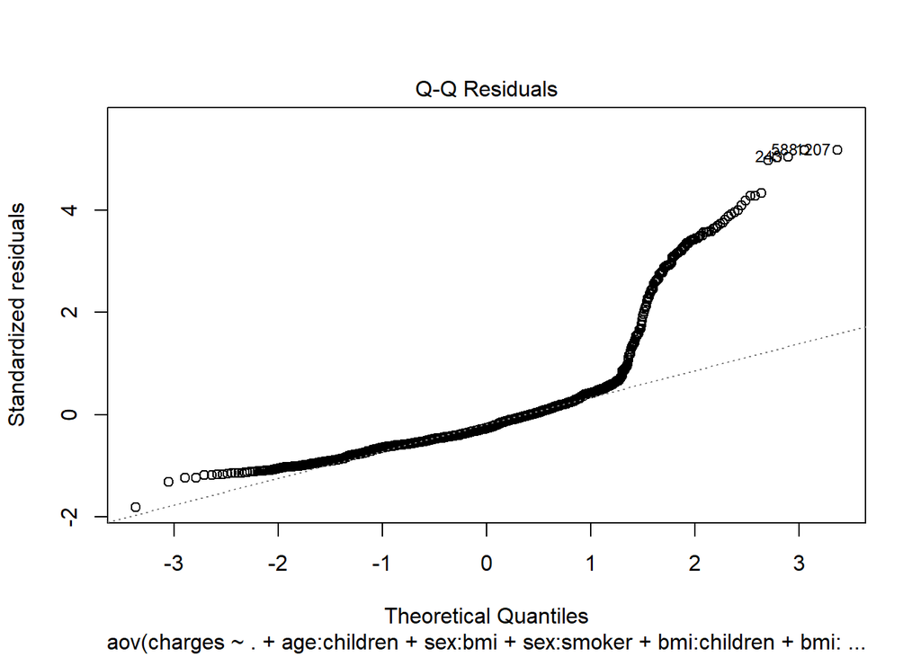

```r
# Kiểm tra giả định mô hình
plot(mod_aov, 2)
```

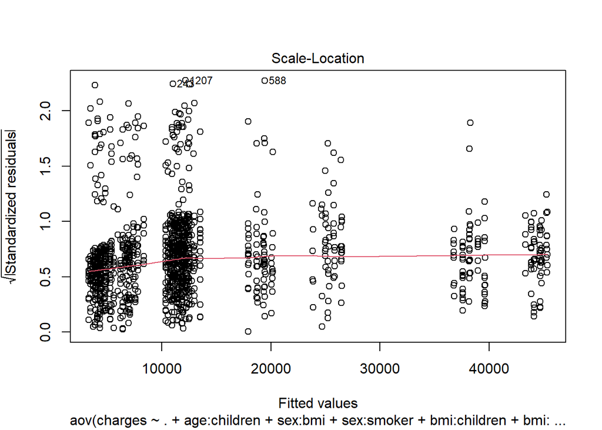

```r
plot(mod_aov, 3)
```

Từ biểu đồ Q - Q plot của các giá trị thặng dư, ta thấy có nhiều điểm nằm xa đường thẳng. Do đó, có vẻ như mô hình đang không thỏa giả định về tính chuẩn.

Từ biểu đồ vẽ căn bậc hai của giá trị thặng dư theo giá trị ước lượng, có thể thấy đường màu đỏ nằm tương đối ngang, và các điểm trên biểu đồ phân bố khá đều xung quanh đường màu đỏ. Do đó, có vẻ như mô hình thỏa giả định về tính ổn định phương sai.

Nay ta đi kiểm tra lại giả định về tính chuẩn và tính ổn định phương sai bằng các kiểm định:

```r
# Kiểm định Shapiro - Wilk
shapiro.test(resid(mod_aov))
```

```
##
##  Shapiro-Wilk normality test
##
## data:  resid(mod_aov)
## W = 0.726, p-value < 2.2e-16
```

Kiểm định Shapiro - Wilk có:

H<sub>0</sub> : Các sai số cùng tuân theo phân phối chuẩn.

H<sub>1</sub> : Các sai số không cùng tuân theo phân phối chuẩn.

Ở đây, vì p - value < 2.2 x 10<sup>-16</sup> < 0.05 nên ta bác bỏ H<sub>0</sub> với mức ý nghĩa 0.05. Và ta kết luận rằng mô hình không thỏa giả định về tính chuẩn.

```r
# Kiểm định Levene's Test
leveneTest(charges ~ .^2 - age:sex - age:smoker - age:bmi - age:region - sex:children - sex:region - bmi:region - children:region, data = insurance)
```

|  | Df | F value | Pr(>F) |
| --- | --- | --- | --- |
| group | 127 | 0.6931792 | 0.995433 |
|  | 1203 | NA | NA |

Kiểm định Levene’s Test có:

H<sub>0</sub> : Phương sai của các nhóm bằng nhau.

H<sub>1</sub> : Phương sai của các nhóm không bằng nhau.

Ở đây, vì p - value = 0.995 > 0.05 nên ta chưa đủ cơ sở để bác bỏ H<sub>0</sub> với mức ý nghĩa 0.05. Và ta kết luận rằng mô hình thỏa giả định về tính ổn định phương sai.

Như vậy, mô hình của chúng ta đang không thỏa giả định về tính chuẩn nên ta sẽ biến đổi biến phụ thuộc “charges”. Đồng thời, vì biến “charges” chỉ có các giá trị dương nên ta sẽ áp dụng phương pháp Box - Cox để biến đổi biến:

```r
# Biến đổi biến bằng Box - Cox
summary(powerTransform(mod_aov))
```

```
## bcPower Transformation to Normality
##    Est Power Rounded Pwr Wald Lwr Bnd Wald Upr Bnd
## Y1    0.3513        0.33       0.2953       0.4074
##
## Likelihood ratio test that transformation parameter is equal to 0
##  (log transformation)
##                            LRT df       pval
## LR test, lambda = (0) 152.8247  1 < 2.22e-16
##
## Likelihood ratio test that no transformation is needed
##                            LRT df       pval
## LR test, lambda = (1) 484.6095  1 < 2.22e-16
```

Khi làm tròn cột Est Power trong kết quả hàm summary(), ta được giá trị $\lambda$ cho biến “charges” là : $\lambda = 0.33$. Ta đi kiểm định:

*H<sub>0</sub> : Thực hiện phép biến đổi theo* $\lambda = 0.33$ *là cần thiết.*

*H<sub>1</sub> : Thực hiện phép biến đổi theo* $\lambda = 0.33$ *là không cần thiết.*

```r
# Kiểm định cho sự biến đổi biến
testTransform(powerTransform(mod_aov), 0.33)
```

|  | LRT | df | pval |
| --- | --- | --- | --- |
| LR test, lambda = (0.33) | 0.5559466 | 1 | 0.4559 |

Vì p - value = 0.456 > 0.05 nên ta không đủ cơ sở để bác bỏ H<sub>0</sub> với mức ý nghĩa 0.05, và kết luận rằng phép biến đổi theo $\lambda = 0.33$ là phù hợp. Ta có mô hình sau khi biến đổi là:

```r
# Mô hình sau khi biến đổi biến
mod_trans <- aov((charges^(0.33)-1)/(0.33) ~ . + age:children + sex:bmi + sex:smoker + bmi:children + bmi:smoker + children:smoker + smoker:region, data = insurance)
summary(mod_trans)
```

```
##                   Df Sum Sq Mean Sq  F value   Pr(>F)
## age                1  74539   74539  908.226  < 2e-16 ***
## sex                1    554     554    6.756 0.009448 **
## bmi                1   6145    6145   74.873  < 2e-16 ***
## children           1   7788    7788   94.891  < 2e-16 ***
## smoker             1 258415  258415 3148.690  < 2e-16 ***
## region             3    947     316    3.847 0.009331 **
## age:children       1   4073    4073   49.625 3.00e-12 ***
## sex:bmi            1    288     288    3.504 0.061444 .
## sex:smoker         1    926     926   11.279 0.000806 ***
## bmi:children       1     79      79    0.965 0.326151
## bmi:smoker         1  16709   16709  203.593  < 2e-16 ***
## children:smoker    1   1500    1500   18.272 2.05e-05 ***
## smoker:region      3    840     280    3.411 0.016955 *
## Residuals       1313 107759      82
## ---
## Signif. codes:  0 '***' 0.001 '**' 0.01 '*' 0.05 '.' 0.1 ' ' 1
```

Nay, ta kiểm tra lại các giả định của mô hình:

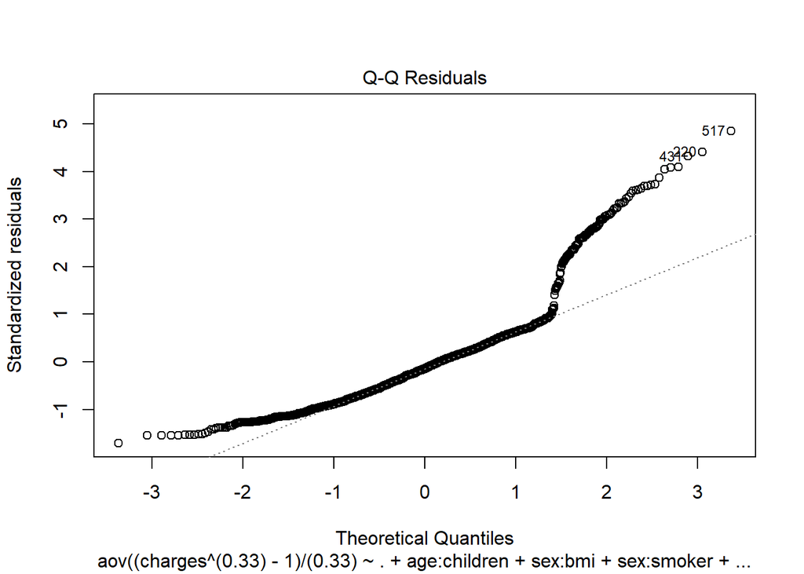

```r
# Kiểm tra lại giả định mô hình
plot(mod_trans,2)
```

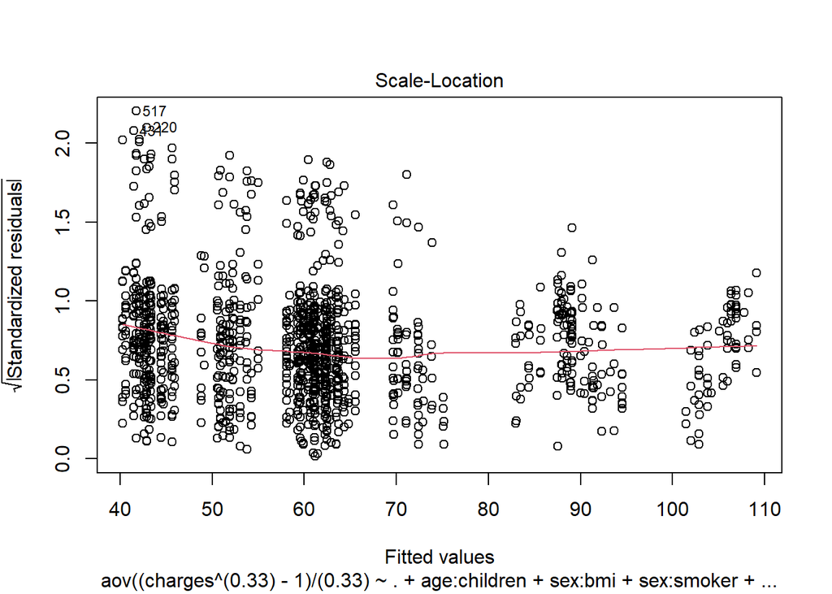

```r
plot(mod_trans,3)
```

Từ biểu đồ Q - Q plot của các giá trị thặng dư, ta thấy vẫn có nhiều điểm nằm xa đường thẳng. Do đó, có vẻ như mô hình vẫn đang không thỏa giả định về tính chuẩn.

Từ biểu đồ vẽ căn bậc hai của giá trị thặng dư theo giá trị ước lượng, có thể thấy đường màu đỏ nằm tương đối ngang, và các điểm trên biểu đồ phân bố khá đều xung quanh đường màu đỏ. Do đó, có vẻ như mô hình thỏa giả định về tính ổn định phương sai.

```r
# Kiểm định Shapiro - Wilk
shapiro.test(resid(mod_trans))
```

```
##
##  Shapiro-Wilk normality test
##
## data:  resid(mod_trans)
## W = 0.864, p-value < 2.2e-16
```

Kiểm định Shapiro - Wilk có:

H<sub>0</sub> : Các sai số cùng tuân theo phân phối chuẩn.

H<sub>1</sub> : Các sai số không cùng tuân theo phân phối chuẩn.

Ở đây, vì p - value < 2.2 x 10<sup>-16</sup>< 0.05 nên ta bác bỏ H<sub>0</sub> với mức ý nghĩa 0.05. Và ta kết luận rằng mô hình không thỏa giả định về tính chuẩn.

```r
# Kiểm định Levene's Test
leveneTest((charges^(0.33)-1)/(0.33) ~ .^2 - age:sex - age:smoker - age:bmi - age:region - sex:children - sex:region - bmi:region - children:region , data = insurance)
```

|  | Df | F value | Pr(>F) |
| --- | --- | --- | --- |
| group | 127 | 1.080497 | 0.2649688 |
|  | 1203 | NA | NA |

Kiểm định Levene’s Test có:

H<sub>0</sub> : Phương sai của các nhóm bằng nhau.

H<sub>1</sub> : Phương sai của các nhóm không bằng nhau.

Ở đây, vì p - value = 0.265 > 0.05 nên ta chưa đủ cơ sở để bác bỏ H<sub>0</sub> với mức ý nghĩa 0.05. Và ta kết luận rằng mô hình thỏa giả định về tính ổn định phương sai.

Ta thấy rằng sau khi biến đổi biến thì mô hình vẫn không thỏa giả định về tính chuẩn, thậm chí p - value của kiểm định Levene’s Test cho tính ổn định phương sai còn bị giảm. Do đó, ta kết luận rằng mô hình trước khi biến đổi biến mod_aov là mô hình ANOVA tốt nhất để phân tích ảnh hưởng của các nhân tố lên biến “charges”.

### (d) Đề xuất những phương pháp cải tiến / phân tích khác có thể cho kết quả tốt hơn:

Đầu tiên, vì giả định về phân phối chuẩn không thỏa nên thay vì dùng ANOVA thì ta có thể thử sử dụng mô hình GLM (mô hình tuyến tính tổng quát) để biểu diễn mối liên hệ giữa biến phụ thuộc charges và các biến độc lập, vì mô hình GLM không yêu cầu giả định về tính chuẩn hay giả định về tính ổn định phương sai. Tuy nhiên, lưu ý rằng mô hình GLM cần thỏa giả định về tính tuyến tính như sau: *“Tồn tại mối quan hệ tuyến tính giữa biến phụ thuộc sau khi được biến đổi theo hàm liên kết với các biến độc lập.”* (giả định này khác với giả định về tính tuyến tính trong mô hình hồi quy tuyến tính)

Thứ hai, thay vì dùng ANOVA thì ta cũng có thể xem xét sử dụng các phương pháp phi tham số. Hiện tại, chưa có phương pháp phi tham số nào được xem là tương đương với phương pháp ANOVA k nhân tố ($k \geq 3$). Tuy nhiên, ta có thể kết hợp sử dụng một số phương pháp phi tham số rồi so sánh lại kết quả với phương pháp ANOVA k nhân tố, ví dụ như:

1. Kiểm định Kruskal-Wallis (tương đương với phương pháp ANOVA 1 nhân tố):

   H<sub>0</sub> : Không có sự khác biệt về trung bình hạng giữa các nhóm.

   H<sub>1</sub> : Có sự khác biệt về trung bình hạng giữa các nhóm.

   Ghi chú: Trong kiểm định phi tham số, dữ liệu thường được xếp hạng, sau đó mỗi quan trắc trong từng nhóm sẽ được gán một hạng. Và trung bình hạng của mỗi nhóm sẽ chính là trung bình các hạng của các quan trắc trong nhóm đó.
2. Phương pháp ANCOVA:

   Mô hình ANCOVA có bao gồm cả các nhân tố và biến số liên tục, giúp kiểm soát tác động của các biến số liên tục nhằm tách biệt được tác động của các nhân tố lên biến phụ thuộc. Ở đây, vì trong bộ dữ liệu insurance có một vài biến số liên tục nên ta có thể thử sử dụng phương pháp ANCOVA.

### Kết luận:

Tuy nhiên, vì giả định về tính chuẩn của mô hình mod_aov không được thỏa nên ta cần cân nhắc kỹ khi sử dụng mô hình này để đưa ra suy luận. Đồng thời, ta cũng có thể thử áp dụng một mô hình hoặc phương pháp khác phù hợp hơn cho bộ dữ liệu insurance.csv.

### Tài liệu tham khảo

[1] [https://online.stat.psu.edu/stat502/lesson/5/5.](https://online.stat.psu.edu/stat502/lesson/5/5.2)2